# CL Match day 4 Season 2627

Result

| Fenerbahce Greenwood 29' Brown 73' Muriqi 79' | 3 – 2 | Liverpool Nyoni 25' Isak 69' |
| --- | --- | --- |

Fenerbahce vs Liverpool - 04-11-2026 | Champions League MD 4

Fenerbahce beat Liverpool 3–2 despite trailing on xG (1.78 vs 1.81). Fenerbahce's peak field tilt was 59% in the 2nd Quarter. Liverpool's peak field tilt was 86% in the 1st Quarter.

xG

FEN 1.78 – 1.81 LIV

xGOT

FEN 2.84 – 1.19 LIV

Field Tilt %

FEN 33% – 67% LIV

PPDA (lower = more intense press)

FEN 17.10 – 9.14 LIV

EPV

FEN 1.68 – 3.23 LIV

EPV to xG Conversion %

FEN 106% – 56% LIV

xG Race

[figure not shown]

Match Momentum

[figure not shown]

Threat Race

[figure not shown]

Field Tilt Momentum

[figure not shown]

Match Report

Summary

- Fenerbahce beat Liverpool 3–2 despite trailing on xG (1.78 vs 1.81). Fenerbahce's peak field tilt was 59% in the 2nd Quarter. Liverpool's peak field tilt was 86% in the 1st Quarter.

Set pieces

- **Fenerbahce** took 4 corners (1 short), winning first contact on 1 of 3 direct deliveries. Set pieces produced 9 shots worth 0.79 xG and 3 goals (44% of their xG).

- **Liverpool** took 12 corners, winning first contact on 1 of 12 direct deliveries. Set pieces produced 6 shots worth 0.55 xG (30% of their xG).

Transitions

- **Fenerbahce** won the ball in open play 78 times (4 in the attacking third) and had 6 shots within 15 seconds of a regain, worth 0.87 xG.

- **Liverpool** won the ball in open play 86 times (8 in the attacking third) and had 8 shots within 15 seconds of a regain, worth 0.55 xG.

Defensive shape

- **Fenerbahce**'s defensive actions pushed up from an average of 27.5m to 37.4m from their own goal between the 1st Quarter and the 2nd Quarter (score 0-1 at the start of the 2nd Quarter), while **Liverpool** went from 39.8m to 45.1m over the 2nd Quarter to 3rd Quarter. Standard PPDA: Fenerbahce 17.1, Liverpool 9.14 (lower = more pressing).

Passing chains

- **Fenerbahce** strung together 1 move of 10+ completed passes (8% of their completed passes came in those moves, 0 ended in a shot). Their longest move was 16 passes (5').

- **Liverpool** strung together 14 moves of 10+ completed passes (46% of their completed passes came in those moves, 3 ended in a shot). Their longest move was 27 passes (67').

Threat areas

- **Fenerbahce** generated most threat from the final third, left wing (0.41 EPV, 25%), followed by the final third, right wing (0.27).

- **Liverpool** generated most threat from the final third, left wing (0.89 EPV, 27%), followed by the final third, right wing (0.74).

Pass maps

- **Fenerbahce**'s most used combination was Skriniar to Ederson (11 completed passes), and Skriniar was the hub of the pass map, involved in 51 completed passes.

- **Liverpool**'s most used combination was Nyoni to Gomez (15 completed passes), and Nyoni was the hub of the pass map, involved in 161 completed passes.

Fenerbahce Line up

Fenerbahce vs Liverpool - 04-11-2026

| Mins Played | Shirt Number | Player |
| --- | --- | --- |
| Keeper |  |  |
| 94 | 31 | Ederson |
| Defender |  |  |
| 94 | 3 | Archie Brown |
| 94 | 21 | Kojo Peprah Oppong |
| 94 | 37 | Milan Skriniar |
| 75 | 27 | Nélson Semedo |
| 19 | 18 | Mert Müldür |
| Midfielder |  |  |
| 94 | 5 | Ismail Yüksek |
| 94 | 6 | Mattéo Guendouzi |
| 94 | 91 | N'Golo Kanté |
| Forward |  |  |
| 90 | 11 | Mason Greenwood |
| 76 | 17 | Irfan Can Kahveci |
| 64 | 9 | Romelu Lukaku |
| 30 | 19 | Vedat Muriqi |
| 18 | 7 | Kerem Aktürkoglu |
| 4 | 70 | Oguz Aydin |
| Substitute |  |  |
| 0 | 13 | Tarik Çetin |
| 0 | 34 | Mert Günok |
| 0 | 14 | Yigit Efe Demir |
| 0 | 22 | Levent Mercan |
| 0 | 28 | Bartug Elmaz |
| 0 | 45 | Dorgeles Nene |
| 0 | 77 | Ognjen Mimović |

X @Barts78 · Bluesky @barts78 · Mastodon @DrBarts · GitHub Barts78 · LinkedIn Phil-barter · Data: Opta

Liverpool Line up

Fenerbahce vs Liverpool - 04-11-2026

|  | Shirt Number | Mins Played |
| --- | --- | --- |
| Keeper |  |  |
| Alisson Becker | 1 | 94 |
| Defender |  |  |
| Jérémy Jacquet | 5 | 94 |
| Virgil van Dijk | 4 | 94 |
| Kostas Tsimikas | 21 | 77 |
| Joe Gomez | 2 | 67 |
| Milos Kerkez | 6 | 17 |
| Midfielder |  |  |
| Alexis Mac Allister | 10 | 94 |
| Dominik Szoboszlai | 8 | 94 |
| Trey Nyoni | 42 | 86 |
| Rio Ngumoha | 73 | 67 |
| Víctor Muñoz | 23 | 67 |
| Cody Gakpo | 18 | 27 |
| Florian Wirtz | 7 | 27 |
| Forward |  |  |
| Bradley Barcola | 29 | 94 |
| Alexander Isak | 9 | 27 |
| Lewis Koumas | 67 | 8 |
| Substitute |  |  |
| Giorgi Mamardashvili | 25 | 0 |
| Freddie Woodman | 28 | 0 |
| Ronald Araujo | 33 | 0 |
| Luke Chambers | 44 | 0 |
| James McConnell | 53 | 0 |
| Jayden Danns | 76 | 0 |

X @Barts78 · Bluesky @barts78 · Mastodon @DrBarts · GitHub Barts78 · LinkedIn Phil-barter · Data: Opta

**Match Summary tables**

**Match Summary - Full Time**

Fenerbahce vs Liverpool - 04-11-2026

| Possession Possession % | Possession On Ball Time | Possession Touches | Possession PKBox Touches | Possession Field Tilt % | Shots Total Shots | Shots OFF Shots | Shots SoT | Shots 6yrd box Shots | Shots PK Box Shots | Shots Outside Box Shots | Shots Blocked Shots | Shots BCs | Shots Goals | Shots xG | Shots NPxG | Shots xGOT | Threat EPV | Threat EPV % xG Con. | Threat EPV % NPxG Con. | Passes Attempted Passes | Passes Successful Passes | Passes Pass Success % | Passes Long Passes | Passes Long Ball Rate | Passes Crosses | Passes Cross Success % | Passes Corners | Passes Short Corners | PPDO | … |
| --- | --- | --- | --- | --- | --- | --- | --- | --- | --- | --- | --- | --- | --- | --- | --- | --- | --- | --- | --- | --- | --- | --- | --- | --- | --- | --- | --- | --- | --- | --- |
| Fenerbahce |  |  |  |  |  |  |  |  |  |  |  |  |  |  |  |  |  |  |  |  |  |  |  |  |  |  |  |  |  | … |
| 37.5% | 26.60 | 443 | 18 | 33.0% | 17 | 8 | 6 | 2 | 10 | 7 | 3 | 4 | 3 | 1.78 | 1.78 | 2.84 | 1.68 | 106.0% | 106.0% | 260 | 186 | 71.5% | 49 | 18.9% | 10 | 20.0% | 4 | 1 |  | … |
| Liverpool |  |  |  |  |  |  |  |  |  |  |  |  |  |  |  |  |  |  |  |  |  |  |  |  |  |  |  |  |  | … |
| 62.5% | 48.30 | 737 | 38 | 67.0% | 22 | 11 | 6 | 2 | 19 | 3 | 5 | 3 | 2 | 1.81 | 1.81 | 1.19 | 3.23 | 56.0% | 56.0% | 529 | 473 | 89.4% | 44 | 8.3% | 42 | 23.8% | 12 | 0 | 830 | … |

X @Barts78 · Bluesky @barts78 · Mastodon @DrBarts · GitHub Barts78 · LinkedIn Phil-barter · Data: Opta

**Match Summary - By Half**

Fenerbahce vs Liverpool - 04-11-2026

|  | Possession Possession % | Possession On Ball Time | Possession Touches | Possession PKBox Touches | Possession Field Tilt % | Shots Total Shots | Shots OFF Shots | Shots SoT | Shots 6yrd box Shots | Shots PK Box Shots | Shots Outside Box Shots | Shots Blocked Shots | Shots BCs | Shots Goals | Shots xG | Shots NPxG | Shots xGOT | Threat EPV | Threat EPV % xG Con. | Threat EPV % NPxG Con. | Passes Attempted Passes | Passes Successful Passes | Passes Pass Success % | Passes Long Passes | Passes Long Ball Rate | Passes Crosses | Passes Cross Success % | Passes Corners | Passes Short Corners | … |
| --- | --- | --- | --- | --- | --- | --- | --- | --- | --- | --- | --- | --- | --- | --- | --- | --- | --- | --- | --- | --- | --- | --- | --- | --- | --- | --- | --- | --- | --- | --- |
| First Half |  |  |  |  |  |  |  |  |  |  |  |  |  |  |  |  |  |  |  |  |  |  |  |  |  |  |  |  |  | … |
| Fenerbahce | 36.2% | 12.20 | 216 | 12 | 36.8% | 8 | 5 | 2 | 1 | 6 | 2 | 1 | 1 | 1 | 1.00 | 1.00 | 0.26 | 0.93 | 107.8% | 107.8% | 127 | 91 | 71.7% | 27 | 21.3% | 4 | 0.0% | 2 | 0 | … |
| Liverpool | 63.8% | 25.40 | 380 | 13 | 63.2% | 9 | 5 | 1 | 1 | 8 | 1 | 3 | 2 | 1 | 1.05 | 1.05 | 0.12 | 1.41 | 74.6% | 74.6% | 278 | 249 | 89.6% | 21 | 7.5% | 23 | 13.0% | 6 | 0 | … |
| Second Half |  |  |  |  |  |  |  |  |  |  |  |  |  |  |  |  |  |  |  |  |  |  |  |  |  |  |  |  |  | … |
| Fenerbahce | 38.9% | 14.40 | 227 | 6 | 29.6% | 9 | 3 | 4 | 1 | 4 | 5 | 2 | 3 | 2 | 0.78 | 0.78 | 2.58 | 0.75 | 103.9% | 103.9% | 133 | 95 | 71.4% | 22 | 16.5% | 6 | 33.3% | 2 | 1 | … |
| Liverpool | 61.1% | 22.90 | 357 | 25 | 70.4% | 13 | 6 | 5 | 1 | 11 | 2 | 2 | 1 | 1 | 0.76 | 0.76 | 1.07 | 1.83 | 41.6% | 41.6% | 251 | 224 | 89.2% | 23 | 9.2% | 19 | 36.8% | 6 | 0 | … |

X @Barts78 · Bluesky @barts78 · Mastodon @DrBarts · GitHub Barts78 · LinkedIn Phil-barter · Data: Opta

**Match Summary - By Game Period**

Fenerbahce vs Liverpool - 04-11-2026

|  | Possession Possession % | Possession On Ball Time | Possession Touches | Possession PKBox Touches | Possession Field Tilt % | Shots Total Shots | Shots OFF Shots | Shots ONT Shots | Shots 6yrd box Shots | Shots PK Box Shots | Shots Outside Box Shots | Shots Blocked Shots | Shots BCs | Shots Goals | Shots xG | Shots NPxG | Shots xGOT | Threat EPV | Threat EPV % xG Con. | Threat EPV % NPxG Con. | Passes Attempted Passes | Passes Successful Passes | Passes Pass Success % | Passes Long Passes | Passes Long Ball Rate | Passes Crosses | Passes Cross Success % | Passes Corners | Passes Short Corners | … |
| --- | --- | --- | --- | --- | --- | --- | --- | --- | --- | --- | --- | --- | --- | --- | --- | --- | --- | --- | --- | --- | --- | --- | --- | --- | --- | --- | --- | --- | --- | --- |
| 0 - 15 |  |  |  |  |  |  |  |  |  |  |  |  |  |  |  |  |  |  |  |  |  |  |  |  |  |  |  |  |  | … |
| Fenerbahce | 34.7% | 4.00 | 82 | 1 | 23.5% | 0 | 0 | 0 | 0 | 0 | 0 | 0 | 0 | 0 | 0.00 | 0.00 | 0.00 | 0.10 | 0.0% | 0.0% | 55 | 37 | 67.3% | 12 | 21.8% | 1 | 0.0% | 0 | 0 | … |
| Liverpool | 65.3% | 11.20 | 154 | 6 | 76.5% | 5 | 4 | 0 | 1 | 4 | 1 | 1 | 2 | 0 | 0.79 | 0.79 | 0.00 | 0.58 | 137.4% | 137.4% | 118 | 106 | 89.8% | 7 | 5.9% | 5 | 20.0% | 1 | 0 | … |
| 16 - 30 |  |  |  |  |  |  |  |  |  |  |  |  |  |  |  |  |  |  |  |  |  |  |  |  |  |  |  |  |  | … |
| Fenerbahce | 32.5% | 4.20 | 55 | 3 | 22.8% | 2 | 1 | 1 | 1 | 1 | 1 | 0 | 1 | 1 | 0.68 | 0.68 | 0.15 | 0.45 | 152.5% | 152.5% | 28 | 22 | 78.6% | 6 | 21.4% | 0 | 0.0% | 0 | 0 | … |
| Liverpool | 67.5% | 7.30 | 114 | 5 | 77.2% | 3 | 0 | 1 | 0 | 3 | 0 | 2 | 0 | 1 | 0.20 | 0.20 | 0.12 | 0.47 | 42.3% | 42.3% | 87 | 82 | 94.3% | 6 | 6.9% | 12 | 8.3% | 3 | 0 | … |
| 31 - 45 |  |  |  |  |  |  |  |  |  |  |  |  |  |  |  |  |  |  |  |  |  |  |  |  |  |  |  |  |  | … |
| Fenerbahce | 41.4% | 4.00 | 79 | 8 | 60.4% | 6 | 4 | 1 | 0 | 5 | 1 | 1 | 0 | 0 | 0.32 | 0.32 | 0.11 | 0.38 | 83.6% | 83.6% | 44 | 32 | 72.7% | 9 | 20.4% | 3 | 0.0% | 2 | 0 | … |
| Liverpool | 58.6% | 6.80 | 112 | 2 | 39.6% | 1 | 1 | 0 | 0 | 1 | 0 | 0 | 0 | 0 | 0.06 | 0.06 | 0.00 | 0.36 | 16.7% | 16.7% | 73 | 61 | 83.6% | 8 | 11.0% | 6 | 16.7% | 2 | 0 | … |
| 46 - 60 |  |  |  |  |  |  |  |  |  |  |  |  |  |  |  |  |  |  |  |  |  |  |  |  |  |  |  |  |  | … |
| Fenerbahce | 37.6% | 4.30 | 82 | 2 | 12.7% | 2 | 0 | 2 | 0 | 2 | 0 | 0 | 0 | 0 | 0.07 | 0.07 | 0.76 | 0.17 | 41.2% | 41.2% | 40 | 26 | 65.0% | 7 | 17.5% | 1 | 100.0% | 1 | 0 | … |
| Liverpool | 62.4% | 8.40 | 136 | 10 | 87.3% | 6 | 2 | 3 | 0 | 5 | 1 | 1 | 0 | 0 | 0.19 | 0.19 | 0.29 | 0.60 | 31.9% | 31.9% | 97 | 89 | 91.8% | 5 | 5.2% | 8 | 37.5% | 3 | 0 | … |
| 61 - 75 |  |  |  |  |  |  |  |  |  |  |  |  |  |  |  |  |  |  |  |  |  |  |  |  |  |  |  |  |  | … |
| Fenerbahce | 42.9% | 4.70 | 69 | 1 | 50.0% | 4 | 1 | 1 | 1 | 1 | 3 | 2 | 1 | 1 | 0.45 | 0.45 | 0.97 | 0.22 | 208.3% | 208.3% | 50 | 41 | 82.0% | 7 | 14.0% | 2 | 0.0% | 1 | 1 | … |
| Liverpool | 57.1% | 7.00 | 92 | 6 | 50.0% | 2 | 1 | 1 | 1 | 2 | 0 | 0 | 1 | 1 | 0.36 | 0.36 | 0.73 | 0.67 | 54.1% | 54.1% | 63 | 59 | 93.7% | 5 | 7.9% | 3 | 66.7% | 1 | 0 | … |
| 76 - 90 |  |  |  |  |  |  |  |  |  |  |  |  |  |  |  |  |  |  |  |  |  |  |  |  |  |  |  |  |  | … |
| Fenerbahce | 37.6% | 5.00 | 67 | 3 | 36.7% | 3 | 2 | 1 | 0 | 1 | 2 | 0 | 2 | 1 | 0.26 | 0.26 | 0.85 | 0.36 | 72.2% | 72.2% | 39 | 27 | 69.2% | 7 | 17.9% | 3 | 33.3% | 0 | 0 | … |
| Liverpool | 62.4% | 6.30 | 111 | 6 | 63.3% | 3 | 2 | 1 | 0 | 2 | 1 | 0 | 0 | 0 | 0.14 | 0.14 | 0.05 | 0.50 | 28.3% | 28.3% | 78 | 67 | 85.9% | 9 | 11.5% | 6 | 33.3% | 1 | 0 | … |
| 90 + |  |  |  |  |  |  |  |  |  |  |  |  |  |  |  |  |  |  |  |  |  |  |  |  |  |  |  |  |  | … |
| Fenerbahce | 33.3% | 0.40 | 9 | 0 | 0.0% | 0 | 0 | 0 | 0 | 0 | 0 | 0 | 0 | 0 | 0.00 | 0.00 | 0.00 | 0.01 | 0.0% | 0.0% | 4 | 1 | 25.0% | 1 | 25.0% | 0 | 0.0% | 0 | 0 | … |
| Liverpool | 66.7% | 1.10 | 18 | 3 | 100.0% | 2 | 1 | 0 | 0 | 2 | 0 | 1 | 0 | 0 | 0.07 | 0.07 | 0.00 | 0.07 | 98.6% | 98.6% | 13 | 9 | 69.2% | 4 | 30.8% | 2 | 0.0% | 1 | 0 | … |

X @Barts78 · Bluesky @barts78 · Mastodon @DrBarts · GitHub Barts78 · LinkedIn Phil-barter · Data: Opta

**Match Summary - By Game Quarter**

Fenerbahce vs Liverpool - 04-11-2026

|  | Possession Possession % | Possession On Ball Time | Possession Touches | Possession PKBox Touches | Possession Field Tilt % | Shots Total Shots | Shots OFF Shots | Shots ONT Shots | Shots 6yrd box Shots | Shots PK Box Shots | Shots Outside Box Shots | Shots Blocked Shots | Shots BCs | Shots Goals | Shots xG | Shots NPxG | Shots xGOT | Threat EPV | Threat EPV % xG Con. | Threat EPV % NPxG Con. | Passes Attempted Passes | Passes Successful Passes | Passes Pass Success % | Passes Long Passes | Passes Long Ball Rate | Passes Crosses | Passes Cross Success % | Passes Corners | Passes Short Corners | … |
| --- | --- | --- | --- | --- | --- | --- | --- | --- | --- | --- | --- | --- | --- | --- | --- | --- | --- | --- | --- | --- | --- | --- | --- | --- | --- | --- | --- | --- | --- | --- |
| 1st Quarter |  |  |  |  |  |  |  |  |  |  |  |  |  |  |  |  |  |  |  |  |  |  |  |  |  |  |  |  |  | … |
| Fenerbahce | 32.8% | 5.90 | 118 | 2 | 14.1% | 0 | 0 | 0 | 0 | 0 | 0 | 0 | 0 | 0 | 0.00 | 0.00 | 0.00 | 0.17 | 0.0% | 0.0% | 72 | 49 | 68.1% | 16 | 22.2% | 1 | 0.0% | 0 | 0 | … |
| Liverpool | 67.2% | 15.90 | 242 | 11 | 85.9% | 8 | 4 | 1 | 1 | 7 | 1 | 3 | 2 | 1 | 0.99 | 0.99 | 0.12 | 0.97 | 102.0% | 102.0% | 182 | 167 | 91.8% | 11 | 6.0% | 16 | 12.5% | 4 | 0 | … |
| 2nd Quarter |  |  |  |  |  |  |  |  |  |  |  |  |  |  |  |  |  |  |  |  |  |  |  |  |  |  |  |  |  | … |
| Fenerbahce | 41.5% | 6.30 | 98 | 10 | 58.9% | 8 | 5 | 2 | 1 | 6 | 2 | 1 | 1 | 1 | 1.00 | 1.00 | 0.26 | 0.76 | 131.9% | 131.9% | 55 | 42 | 76.4% | 11 | 20.0% | 3 | 0.0% | 2 | 0 | … |
| Liverpool | 58.5% | 9.50 | 138 | 2 | 41.1% | 1 | 1 | 0 | 0 | 1 | 0 | 0 | 0 | 0 | 0.06 | 0.06 | 0.00 | 0.44 | 13.8% | 13.8% | 96 | 82 | 85.4% | 10 | 10.4% | 7 | 14.3% | 2 | 0 | … |
| 3rd Quarter |  |  |  |  |  |  |  |  |  |  |  |  |  |  |  |  |  |  |  |  |  |  |  |  |  |  |  |  |  | … |
| Fenerbahce | 35.8% | 6.40 | 118 | 2 | 19.8% | 4 | 1 | 2 | 0 | 2 | 2 | 1 | 0 | 0 | 0.15 | 0.15 | 0.76 | 0.29 | 51.7% | 51.7% | 64 | 45 | 70.3% | 10 | 15.6% | 3 | 33.3% | 1 | 0 | … |
| Liverpool | 64.2% | 13.80 | 212 | 15 | 80.2% | 8 | 3 | 4 | 1 | 7 | 1 | 1 | 1 | 1 | 0.55 | 0.55 | 1.02 | 1.21 | 45.5% | 45.5% | 152 | 142 | 93.4% | 9 | 5.9% | 11 | 45.5% | 4 | 0 | … |
| 4th Quarter |  |  |  |  |  |  |  |  |  |  |  |  |  |  |  |  |  |  |  |  |  |  |  |  |  |  |  |  |  | … |
| Fenerbahce | 42.9% | 8.00 | 109 | 4 | 39.5% | 5 | 2 | 2 | 1 | 2 | 3 | 1 | 3 | 2 | 0.63 | 0.63 | 1.82 | 0.46 | 136.7% | 136.7% | 69 | 50 | 72.5% | 12 | 17.4% | 3 | 33.3% | 1 | 1 | … |
| Liverpool | 57.1% | 9.00 | 145 | 10 | 60.5% | 5 | 3 | 1 | 0 | 4 | 1 | 1 | 0 | 0 | 0.21 | 0.21 | 0.05 | 0.62 | 34.0% | 34.0% | 99 | 82 | 82.8% | 14 | 14.1% | 8 | 25.0% | 2 | 0 | … |

X @Barts78 · Bluesky @barts78 · Mastodon @DrBarts · GitHub Barts78 · LinkedIn Phil-barter · Data: Opta

**Match Summary - By Game State**

Fenerbahce vs Liverpool - 04-11-2026

|  | Possession Possession % | Possession On Ball Time | Possession Touches | Possession PKBox Touches | Possession Field Tilt % | Shots Total Shots | Shots OFF Shots | Shots SoT | Shots 6yrd box Shots | Shots PK Box Shots | Shots Outside Box Shots | Shots Blocked Shots | Shots BCs | Shots Goals | Shots xG | Shots NPxG | Shots xGOT | Threat EPV | Threat EPV % xG Con. | Threat EPV % NPxG Con. | Passes Attempted Passes | Passes Successful Passes | Passes Pass Success % | Passes Long Passes | Passes Long Ball Rate | Passes Crosses | Passes Cross Success % | Passes Corners | Passes Short Corners | … |
| --- | --- | --- | --- | --- | --- | --- | --- | --- | --- | --- | --- | --- | --- | --- | --- | --- | --- | --- | --- | --- | --- | --- | --- | --- | --- | --- | --- | --- | --- | --- |
| Away Lead |  |  |  |  |  |  |  |  |  |  |  |  |  |  |  |  |  |  |  |  |  |  |  |  |  |  |  |  |  | … |
| Fenerbahce | 67.2% | 4.10 | 45 | 2 | 91.3% | 5 | 1 | 2 | 2 | 2 | 3 | 2 | 2 | 2 | 1.07 | 1.07 | 1.12 | 0.42 | 257.8% | 257.8% | 33 | 30 | 90.9% | 5 | 15.2% | 0 | 0.0% | 1 | 1 | … |
| Liverpool | 32.8% | 3.60 | 22 | 1 | 8.7% | 0 | 0 | 0 | 0 | 0 | 0 | 0 | 0 | 0 | 0.00 | 0.00 | 0.00 | 0.07 | 0.0% | 0.0% | 10 | 9 | 90.0% | 2 | 20.0% | 0 | 0.0% | 0 | 0 | … |
| Draw |  |  |  |  |  |  |  |  |  |  |  |  |  |  |  |  |  |  |  |  |  |  |  |  |  |  |  |  |  | … |
| Fenerbahce | 35.3% | 19.00 | 334 | 15 | 28.4% | 10 | 5 | 4 | 0 | 8 | 2 | 1 | 1 | 1 | 0.61 | 0.61 | 1.72 | 1.14 | 53.5% | 53.5% | 189 | 132 | 69.8% | 37 | 19.6% | 9 | 22.2% | 3 | 0 | … |
| Liverpool | 64.7% | 38.40 | 613 | 28 | 71.6% | 17 | 8 | 5 | 2 | 15 | 2 | 4 | 3 | 2 | 1.60 | 1.60 | 1.14 | 2.65 | 60.3% | 60.3% | 449 | 408 | 90.9% | 29 | 6.5% | 34 | 23.5% | 10 | 0 | … |
| Home Lead |  |  |  |  |  |  |  |  |  |  |  |  |  |  |  |  |  |  |  |  |  |  |  |  |  |  |  |  |  | … |
| Fenerbahce | 38.6% | 3.50 | 64 | 1 | 27.5% | 2 | 2 | 0 | 0 | 0 | 2 | 0 | 1 | 0 | 0.10 | 0.10 | 0.00 | 0.12 | 81.3% | 81.3% | 38 | 24 | 63.2% | 7 | 18.4% | 1 | 0.0% | 0 | 0 | … |
| Liverpool | 61.4% | 6.30 | 102 | 9 | 72.5% | 5 | 3 | 1 | 0 | 4 | 1 | 1 | 0 | 0 | 0.21 | 0.21 | 0.05 | 0.51 | 41.3% | 41.3% | 70 | 56 | 80.0% | 13 | 18.6% | 8 | 25.0% | 2 | 0 | … |

X @Barts78 · Bluesky @barts78 · Mastodon @DrBarts · GitHub Barts78 · LinkedIn Phil-barter · Data: Opta

**Season Summary Tables**

**Season Summary - Full Games**

Up to Fenerbahce vs Liverpool - 04-11-2026

| Possession % | Touches | PKBox Touches | Field Tilt % | Total Shots | OFF Shots | SoT | 6yrd box Shots | PK Box Shots | Outside Box Shots | BCs | Goals | xG | NPxG | xGOT | EPV | EPV % xG Con. | Attempted Passes | Successful Passes | Pass Success % | Long Passes | Long Ball Rate | Crosses | Cross Success % | Corners | Short Corners | Possession Control | Poss Control /100 Touches | EPV % NPxG Con. |
| --- | --- | --- | --- | --- | --- | --- | --- | --- | --- | --- | --- | --- | --- | --- | --- | --- | --- | --- | --- | --- | --- | --- | --- | --- | --- | --- | --- | --- |
| All Oppo |  |  |  |  |  |  |  |  |  |  |  |  |  |  |  |  |  |  |  |  |  |  |  |  |  |  |  |  |
| 44.8% | 2,346 | 83 | 35.8% | 52 | 21 | 19 | 6 | 33 | 19 | 12 | 10 | 6.22 | 6.22 | 7.76 | 6.82 | 91.2% | 1584 | 1292 | 81.6% | 188 | 11.9% | 50 | 20.0% | 14 | 4 | -268 | -11.4 | 91.2% |
| Liverpool |  |  |  |  |  |  |  |  |  |  |  |  |  |  |  |  |  |  |  |  |  |  |  |  |  |  |  |  |
| 55.2% | 2,892 | 169 | 64.2% | 84 | 36 | 26 | 6 | 65 | 19 | 15 | 14 | 9.22 | 9.22 | 10.37 | 12.16 | 75.8% | 2068 | 1816 | 87.8% | 178 | 8.6% | 98 | 23.5% | 37 | 5 | -272 | -9.4 | 75.8% |

X @Barts78 · Bluesky @barts78 · Mastodon @DrBarts · GitHub Barts78 · LinkedIn Phil-barter · Data: Opta

**Season Summary - By Half**

Up to Fenerbahce vs Liverpool - 04-11-2026

|  | Possession Possession % | Possession Touches | Possession PKBox Touches | Possession Field Tilt % | Shots Total Shots | Shots OFF Shots | Shots SoT | Shots 6yrd box Shots | Shots PK Box Shots | Shots Outside Box Shots | Shots BCs | Shots Goals | Shots xG | Shots NPxG | Shots xGOT | Threat EPV | Threat EPV % xG Con. | Threat EPV % NPxG Con. | Passes Attempted Passes | Passes Successful Passes | Passes Pass Success % | Passes Long Passes | Passes Long Ball Rate | Passes Crosses | Passes Cross Success % | Passes Corners | Passes Short Corners | Possession Control | Poss Control /100 Touches | … |
| --- | --- | --- | --- | --- | --- | --- | --- | --- | --- | --- | --- | --- | --- | --- | --- | --- | --- | --- | --- | --- | --- | --- | --- | --- | --- | --- | --- | --- | --- | --- |
| First Half |  |  |  |  |  |  |  |  |  |  |  |  |  |  |  |  |  |  |  |  |  |  |  |  |  |  |  |  |  | … |
| All Oppo | 42.4% | 1,105 | 40 | 28.7% | 27 | 12 | 8 | 3 | 16 | 11 | 4 | 4 | 3.05 | 3.05 | 2.11 | 2.92 | 104.6% | 104.6% | 718 | 568 | 79.1% | 98 | 13.7% | 15 | 20.0% | 8 | 3 |  |  | … |
| Liverpool | 57.6% | 1,500 | 85 | 71.3% | 42 | 19 | 12 | 3 | 32 | 10 | 8 | 7 | 4.35 | 4.35 | 4.92 | 5.69 | 76.5% | 76.5% | 1080 | 949 | 87.9% | 80 | 7.4% | 54 | 16.7% | 20 | 3 | -154 | -10.3 | … |
| Second Half |  |  |  |  |  |  |  |  |  |  |  |  |  |  |  |  |  |  |  |  |  |  |  |  |  |  |  |  |  | … |
| All Oppo | 47.1% | 1,241 | 43 | 42.5% | 25 | 9 | 11 | 3 | 17 | 8 | 8 | 6 | 3.17 | 3.17 | 5.65 | 3.90 | 81.3% | 81.3% | 866 | 724 | 83.6% | 90 | 10.4% | 35 | 20.0% | 6 | 1 | -140 | -11.3 | … |
| Liverpool | 52.9% | 1,392 | 84 | 57.5% | 42 | 17 | 14 | 3 | 33 | 9 | 7 | 7 | 4.87 | 4.87 | 5.45 | 6.48 | 75.2% | 75.2% | 988 | 867 | 87.8% | 98 | 9.9% | 44 | 31.8% | 17 | 2 | -118 | -8.5 | … |

X @Barts78 · Bluesky @barts78 · Mastodon @DrBarts · GitHub Barts78 · LinkedIn Phil-barter · Data: Opta

**Season Summary - By Game Period**

Up to Fenerbahce vs Liverpool - 04-11-2026

|  | Possession Possession % | Possession Touches | Possession PKBox Touches | Possession Field Tilt % | Shots Total Shots | Shots OFF Shots | Shots ONT Shots | Shots 6yrd box Shots | Shots PK Box Shots | Shots Outside Box Shots | Shots BCs | Shots Goals | Shots xG | Shots NPxG | Shots xGOT | Threat EPV | Threat EPV % xG Con. | Threat EPV % NPxG Con. | Passes Attempted Passes | Passes Successful Passes | Passes Pass Success % | Passes Long Passes | Passes Long Ball Rate | Passes Crosses | Passes Cross Success % | Passes Corners | Passes Short Corners | Possession Control | Poss Control /100 Touches | … |
| --- | --- | --- | --- | --- | --- | --- | --- | --- | --- | --- | --- | --- | --- | --- | --- | --- | --- | --- | --- | --- | --- | --- | --- | --- | --- | --- | --- | --- | --- | --- |
| 0 - 15 |  |  |  |  |  |  |  |  |  |  |  |  |  |  |  |  |  |  |  |  |  |  |  |  |  |  |  |  |  | … |
| All Oppo | 44.5% | 440 | 17 | 31.8% | 6 | 2 | 2 | 1 | 4 | 2 | 1 | 1 | 0.54 | 0.54 | 0.60 | 0.98 | 55.3% | 55.3% | 289 | 223 | 77.2% | 37 | 12.8% | 7 | 14.3% | 3 | 1 |  |  | … |
| Liverpool | 55.5% | 549 | 25 | 68.2% | 15 | 9 | 2 | 1 | 11 | 4 | 3 | 0 | 1.38 | 1.38 | 0.40 | 1.62 | 85.3% | 85.3% | 392 | 337 | 86.0% | 34 | 8.7% | 12 | 8.3% | 4 | 1 | -56 | -10.2 | … |
| 16 - 30 |  |  |  |  |  |  |  |  |  |  |  |  |  |  |  |  |  |  |  |  |  |  |  |  |  |  |  |  |  | … |
| All Oppo | 39.1% | 313 | 10 | 19.5% | 9 | 1 | 4 | 1 | 5 | 4 | 3 | 3 | 1.83 | 1.83 | 1.36 | 0.88 | 208.0% | 208.0% | 204 | 169 | 82.8% | 32 | 15.7% | 1 | 0.0% | 1 | 1 | -27 | -8.6 | … |
| Liverpool | 60.9% | 487 | 25 | 80.5% | 9 | 2 | 4 | 0 | 9 | 0 | 0 | 3 | 0.68 | 0.68 | 0.72 | 1.94 | 35.1% | 35.1% | 364 | 334 | 91.8% | 23 | 6.3% | 23 | 17.4% | 8 | 0 | -36 | -7.4 | … |
| 31 - 45 |  |  |  |  |  |  |  |  |  |  |  |  |  |  |  |  |  |  |  |  |  |  |  |  |  |  |  |  |  | … |
| All Oppo | 43.1% | 352 | 13 | 35.1% | 12 | 9 | 2 | 1 | 7 | 5 | 0 | 0 | 0.68 | 0.68 | 0.15 | 1.06 | 64.2% | 64.2% | 225 | 176 | 78.2% | 29 | 12.9% | 7 | 28.6% | 4 | 1 | -38 | -10.8 | … |
| Liverpool | 56.9% | 464 | 35 | 64.9% | 18 | 8 | 6 | 2 | 12 | 6 | 5 | 4 | 2.29 | 2.29 | 3.80 | 2.13 | 107.4% | 107.4% | 324 | 278 | 85.8% | 23 | 7.1% | 19 | 21.1% | 8 | 2 | -62 | -13.4 | … |
| 46 - 60 |  |  |  |  |  |  |  |  |  |  |  |  |  |  |  |  |  |  |  |  |  |  |  |  |  |  |  |  |  | … |
| All Oppo | 39.2% | 354 | 6 | 20.7% | 5 | 1 | 3 | 0 | 4 | 1 | 0 | 0 | 0.25 | 0.25 | 0.93 | 0.51 | 48.9% | 48.9% | 205 | 154 | 75.1% | 27 | 13.2% | 8 | 12.5% | 2 | 0 | -38 | -10.7 | … |
| Liverpool | 60.8% | 549 | 36 | 79.3% | 18 | 7 | 7 | 0 | 11 | 7 | 1 | 2 | 1.06 | 1.06 | 1.57 | 1.85 | 57.3% | 57.3% | 403 | 359 | 89.1% | 26 | 6.5% | 23 | 21.7% | 8 | 1 | -49 | -8.9 | … |
| 61 - 75 |  |  |  |  |  |  |  |  |  |  |  |  |  |  |  |  |  |  |  |  |  |  |  |  |  |  |  |  |  | … |
| All Oppo | 51.0% | 395 | 21 | 51.9% | 10 | 2 | 5 | 2 | 6 | 4 | 4 | 3 | 1.95 | 1.95 | 2.62 | 1.33 | 146.9% | 146.9% | 309 | 270 | 87.4% | 27 | 8.7% | 11 | 9.1% | 2 | 1 | -47 | -11.9 | … |
| Liverpool | 49.0% | 380 | 26 | 48.1% | 13 | 4 | 5 | 3 | 12 | 1 | 6 | 5 | 3.14 | 3.14 | 3.45 | 2.40 | 130.8% | 130.8% | 260 | 233 | 89.6% | 29 | 11.2% | 7 | 57.1% | 3 | 0 | -20 | -5.3 | … |
| 76 - 90 |  |  |  |  |  |  |  |  |  |  |  |  |  |  |  |  |  |  |  |  |  |  |  |  |  |  |  |  |  | … |
| All Oppo | 53.5% | 419 | 14 | 56.9% | 9 | 6 | 3 | 1 | 7 | 2 | 4 | 3 | 0.92 | 0.92 | 2.10 | 1.91 | 48.1% | 48.1% | 302 | 261 | 86.4% | 29 | 9.6% | 15 | 33.3% | 2 | 0 | -44 | -10.5 | … |
| Liverpool | 46.5% | 364 | 17 | 43.1% | 9 | 5 | 2 | 0 | 8 | 1 | 0 | 0 | 0.60 | 0.60 | 0.43 | 1.92 | 31.3% | 31.3% | 245 | 208 | 84.9% | 31 | 12.7% | 12 | 41.7% | 5 | 1 | -36 | -9.9 | … |
| 90 + |  |  |  |  |  |  |  |  |  |  |  |  |  |  |  |  |  |  |  |  |  |  |  |  |  |  |  |  |  | … |
| All Oppo | 42.4% | 73 | 2 | 25.8% | 1 | 0 | 0 | 0 | 0 | 1 | 0 | 0 | 0.05 | 0.05 | 0.00 | 0.15 | 33.6% | 33.6% | 50 | 39 | 78.0% | 7 | 14.0% | 1 | 0.0% | 0 | 0 | -11 | -15.1 | … |
| Liverpool | 57.6% | 99 | 5 | 74.2% | 2 | 1 | 0 | 0 | 2 | 0 | 0 | 0 | 0.07 | 0.07 | 0.00 | 0.31 | 22.7% | 22.7% | 80 | 67 | 83.8% | 12 | 15.0% | 2 | 0.0% | 1 | 0 | -13 | -13.1 | … |

X @Barts78 · Bluesky @barts78 · Mastodon @DrBarts · GitHub Barts78 · LinkedIn Phil-barter · Data: Opta

**Season Summary - By Game State**

Up to Fenerbahce vs Liverpool - 04-11-2026

|  | Possession Possession % | Possession Touches | Possession PKBox Touches | Possession Field Tilt % | Shots Total Shots | Shots OFF Shots | Shots SoT | Shots 6yrd box Shots | Shots PK Box Shots | Shots Outside Box Shots | Shots BCs | Shots Goals | Shots xG | Shots NPxG | Shots xGOT | Threat EPV | Threat EPV % xG Con. | Threat EPV % NPxG Con. | Passes Attempted Passes | Passes Successful Passes | Passes Pass Success % | Passes Long Passes | Passes Long Ball Rate | Passes Crosses | Passes Cross Success % | Passes Corners | Passes Short Corners | Possession Control | Poss Control /100 Touches | … |
| --- | --- | --- | --- | --- | --- | --- | --- | --- | --- | --- | --- | --- | --- | --- | --- | --- | --- | --- | --- | --- | --- | --- | --- | --- | --- | --- | --- | --- | --- | --- |
| Away Garbage Time |  |  |  |  |  |  |  |  |  |  |  |  |  |  |  |  |  |  |  |  |  |  |  |  |  |  |  |  |  | … |
| All Oppo | 41.5% | 432 | 16 | 39.8% | 11 | 7 | 4 | 2 | 9 | 2 | 4 | 3 | 1.90 | 1.90 | 2.18 | 1.34 | 142.2% | 142.2% | 305 | 259 | 84.9% | 26 | 8.5% | 13 | 15.4% | 1 | 0 |  |  | … |
| Liverpool | 58.5% | 609 | 36 | 60.2% | 17 | 7 | 6 | 2 | 13 | 4 | 5 | 5 | 2.83 | 2.83 | 4.02 | 2.93 | 96.5% | 96.5% | 463 | 422 | 91.1% | 32 | 6.9% | 14 | 42.9% | 7 | 3 | -46 | -7.6 | … |
| Away Lead |  |  |  |  |  |  |  |  |  |  |  |  |  |  |  |  |  |  |  |  |  |  |  |  |  |  |  |  |  | … |
| All Oppo | 44.9% | 425 | 11 | 25.0% | 13 | 1 | 5 | 2 | 7 | 6 | 3 | 3 | 2.00 | 2.00 | 2.10 | 1.09 | 184.0% | 184.0% | 283 | 226 | 79.9% | 40 | 14.1% | 2 | 0.0% | 4 | 3 | -52 | -12.2 | … |
| Liverpool | 55.1% | 521 | 33 | 75.0% | 12 | 3 | 5 | 1 | 10 | 2 | 3 | 3 | 1.44 | 1.44 | 2.16 | 1.83 | 78.8% | 78.8% | 369 | 321 | 87.0% | 25 | 6.8% | 15 | 13.3% | 4 | 0 | -43 | -8.3 | … |
| Draw |  |  |  |  |  |  |  |  |  |  |  |  |  |  |  |  |  |  |  |  |  |  |  |  |  |  |  |  |  | … |
| All Oppo | 39.4% | 812 | 30 | 27.0% | 18 | 8 | 7 | 1 | 11 | 7 | 3 | 3 | 1.55 | 1.55 | 2.59 | 2.14 | 72.6% | 72.6% | 487 | 368 | 75.6% | 74 | 15.2% | 18 | 22.2% | 6 | 1 | -94 | -11.6 | … |
| Liverpool | 60.6% | 1,250 | 71 | 73.0% | 41 | 19 | 12 | 3 | 29 | 12 | 6 | 5 | 3.98 | 3.98 | 3.31 | 5.17 | 76.9% | 76.9% | 908 | 808 | 89.0% | 66 | 7.3% | 53 | 20.8% | 21 | 2 | -134 | -10.7 | … |
| Home Garbage Time |  |  |  |  |  |  |  |  |  |  |  |  |  |  |  |  |  |  |  |  |  |  |  |  |  |  |  |  |  | … |
| All Oppo | 61.7% | 182 | 9 | 63.7% | 4 | 1 | 2 | 0 | 3 | 1 | 1 | 1 | 0.37 | 0.37 | 0.77 | 0.76 | 48.6% | 48.6% | 140 | 129 | 92.1% | 10 | 7.1% | 3 | 33.3% | 0 | 0 | -17 | -9.3 | … |
| Liverpool | 38.3% | 113 | 9 | 36.3% | 3 | 2 | 0 | 0 | 3 | 0 | 0 | 0 | 0.16 | 0.16 | 0.00 | 0.44 | 36.6% | 36.6% | 76 | 63 | 82.9% | 13 | 17.1% | 1 | 0.0% | 0 | 0 | -4 | -3.5 | … |
| Home Lead |  |  |  |  |  |  |  |  |  |  |  |  |  |  |  |  |  |  |  |  |  |  |  |  |  |  |  |  |  | … |
| All Oppo | 55.4% | 495 | 17 | 51.9% | 6 | 4 | 1 | 1 | 3 | 3 | 1 | 0 | 0.40 | 0.40 | 0.12 | 1.50 | 26.7% | 26.7% | 369 | 310 | 84.0% | 38 | 10.3% | 14 | 21.4% | 3 | 0 | -62 | -12.5 | … |
| Liverpool | 44.6% | 399 | 20 | 48.1% | 11 | 5 | 3 | 0 | 10 | 1 | 1 | 1 | 0.81 | 0.81 | 0.88 | 1.79 | 45.2% | 45.2% | 252 | 202 | 80.2% | 42 | 16.7% | 15 | 26.7% | 5 | 0 | -45 | -11.3 | … |

X @Barts78 · Bluesky @barts78 · Mastodon @DrBarts · GitHub Barts78 · LinkedIn Phil-barter · Data: Opta

**Season Summary - By Match Day**

Up to Fenerbahce vs Liverpool - 04-11-2026

|  | Fixture | Possession Possession % | Possession Touches | Possession PKBox Touches | Possession Field Tilt % | Shots Total Shots | Shots OFF Shots | Shots SoT | Shots 6yrd box Shots | Shots PK Box Shots | Shots Outside Box Shots | Shots BCs | Shots Goals | Shots xG | Shots NPxG | Shots xGOT | Threat EPV | Threat EPV % xG Con. | Threat EPV % NPxG Con. | Passes Attempted Passes | Passes Successful Passes | Passes Pass Success % | Passes Long Passes | Passes Long Ball Rate | Passes Crosses | Passes Cross Success % | Passes Corners | Passes Short Corners | Possession Control | … |
| --- | --- | --- | --- | --- | --- | --- | --- | --- | --- | --- | --- | --- | --- | --- | --- | --- | --- | --- | --- | --- | --- | --- | --- | --- | --- | --- | --- | --- | --- | --- |
| 1 |  |  |  |  |  |  |  |  |  |  |  |  |  |  |  |  |  |  |  |  |  |  |  |  |  |  |  |  |  | … |
| All Oppo | Liverpool vs Atletico | 53.2% | 708 | 19 | 41.2% | 9 | 4 | 4 | 1 | 4 | 5 | 1 | 1 | 0.81 | 0.81 | 0.60 | 1.84 | 44.0% | 44.0% | 515 | 438 | 85.0% | 54 | 10.5% | 15 | 26.7% | 5 | 1 |  | … |
| Liverpool | Liverpool vs Atletico | 46.8% | 622 | 35 | 58.8% | 14 | 5 | 5 | 0 | 12 | 2 | 4 | 2 | 1.70 | 1.70 | 1.63 | 2.30 | 74.0% | 74.0% | 421 | 355 | 84.3% | 50 | 11.9% | 17 | 17.6% | 7 | 2 | -68 | … |
| 2 |  |  |  |  |  |  |  |  |  |  |  |  |  |  |  |  |  |  |  |  |  |  |  |  |  |  |  |  |  | … |
| All Oppo | LASK vs Liverpool | 38.1% | 479 | 24 | 35.4% | 12 | 7 | 4 | 3 | 10 | 2 | 4 | 3 | 2.02 | 2.02 | 2.18 | 1.63 | 123.6% | 123.6% | 310 | 251 | 81.0% | 35 | 11.3% | 17 | 17.6% | 3 | 1 | -63 | … |
| Liverpool | LASK vs Liverpool | 61.9% | 778 | 51 | 64.6% | 26 | 12 | 8 | 2 | 20 | 6 | 5 | 6 | 3.33 | 3.33 | 3.70 | 3.71 | 89.8% | 89.8% | 576 | 524 | 91.0% | 41 | 7.1% | 19 | 36.8% | 11 | 3 | -67 | … |
| 3 |  |  |  |  |  |  |  |  |  |  |  |  |  |  |  |  |  |  |  |  |  |  |  |  |  |  |  |  |  | … |
| All Oppo | Liverpool vs Villarreal | 48.7% | 716 | 22 | 33.9% | 14 | 2 | 5 | 0 | 9 | 5 | 3 | 3 | 1.61 | 1.61 | 2.14 | 1.66 | 96.9% | 96.9% | 499 | 417 | 83.6% | 50 | 10.0% | 8 | 12.5% | 2 | 1 | -83 | … |
| Liverpool | Liverpool vs Villarreal | 51.3% | 755 | 45 | 66.1% | 22 | 8 | 7 | 2 | 14 | 8 | 3 | 4 | 2.38 | 2.38 | 3.85 | 2.92 | 81.4% | 81.4% | 542 | 464 | 85.6% | 43 | 7.9% | 20 | 15.0% | 7 | 0 | -51 | … |
| 4 |  |  |  |  |  |  |  |  |  |  |  |  |  |  |  |  |  |  |  |  |  |  |  |  |  |  |  |  |  | … |
| All Oppo | Fenerbahce vs Liverpool | 37.5% | 443 | 18 | 33.0% | 17 | 8 | 6 | 2 | 10 | 7 | 4 | 3 | 1.78 | 1.78 | 2.84 | 1.68 | 106.0% | 106.0% | 260 | 186 | 71.5% | 49 | 18.9% | 10 | 20.0% | 4 | 1 | -58 | … |
| Liverpool | Fenerbahce vs Liverpool | 62.5% | 737 | 38 | 67.0% | 22 | 11 | 6 | 2 | 19 | 3 | 3 | 2 | 1.81 | 1.81 | 1.19 | 3.23 | 56.0% | 56.0% | 529 | 473 | 89.4% | 44 | 8.3% | 42 | 23.8% | 12 | 0 | -86 | … |

X @Barts78 · Bluesky @barts78 · Mastodon @DrBarts · GitHub Barts78 · LinkedIn Phil-barter · Data: Opta

**Match Goals Probablity xG only**

[figure not shown]

**Match Goals Probablity Blended**

[figure not shown]

**Match Goals Probablity Optimistic**

[figure not shown]

**Match Goals Probablity Pessimistic**

[figure not shown]

**Match Result Probablity - All Models**

[figure not shown]

**Match Result Probablity xG only**

[figure not shown]

**Match Result Probablity Blended**

[figure not shown]

**Match Result Probablity Optimistic**

[figure not shown]

**Match Result Probablity Pessimistic**

[figure not shown]

Home Match territory plot

[figure not shown]

Away Match teratitory plot

[figure not shown]

Substitution Impact

**Substitution Impact - Before and After Each Sub Window**

Fenerbahce vs Liverpool - 04-11-2026 | xG and EPV per 10 minutes, field tilt and PPDA within each window

|  | Mins | Subs on | Score | Fenerbahce xG/10 | Fenerbahce EPV/10 | Fenerbahce Field tilt % | Fenerbahce PPDA | Liverpool xG/10 | Liverpool EPV/10 | Liverpool Field tilt % | Liverpool PPDA |
| --- | --- | --- | --- | --- | --- | --- | --- | --- | --- | --- | --- |
| 0'-64' | 64 | Starting XIs | 0-0 | 0.17 | 0.17 | 29% | 16.81 | 0.20 | 0.33 | 71% | 9.71 |
| 64'-75' | 11 | FEN: Muriqi \| LIV: Wirtz, Isak, Gakpo | 1-1 | 0.41 | 0.16 | 60% | 18.00 | 0.27 | 0.51 | 40% | 7.00 |
| 75'-86' | 11 | FEN: Müldür, Aktürkoglu \| LIV: Kerkez | 2-2 | 0.15 | 0.28 | 26% | 30.00 | 0.05 | 0.28 | 74% | 7.67 |
| 86'-90' | 4 | LIV: Koumas | 3-2 | 0.12 | 0.13 | 59% | 7.00 | 0.20 | 0.41 | 41% | - |
| 90'-94' | 5 | FEN: Aydin | 3-2 | 0.10 | 0.08 | 21% | 17.00 | 0.14 | 0.21 | 79% | 12.00 |

Windows split at each substitution (subs within 3 minutes are grouped). Short windows are noisy, so read alongside the minutes column.  
X @Barts78 · Bluesky @barts78 · Mastodon @DrBarts · GitHub Barts78 · LinkedIn Phil-barter · Data: Opta

Match vs Season Average

[figure not shown]

Home Pass Maps

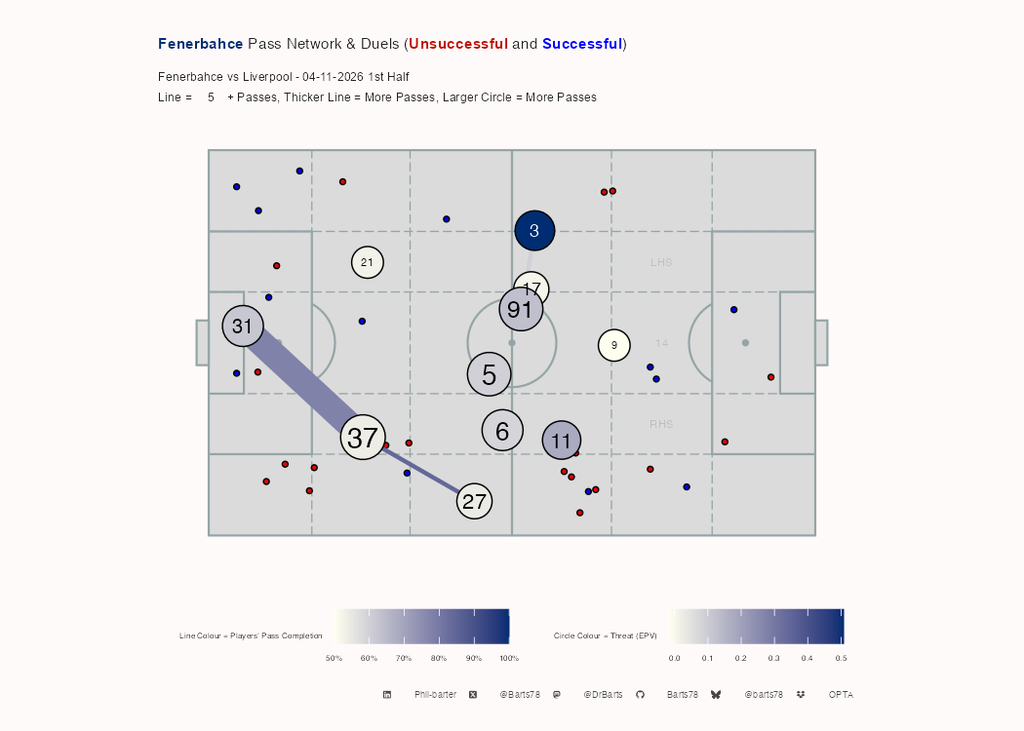

Away Pass Maps

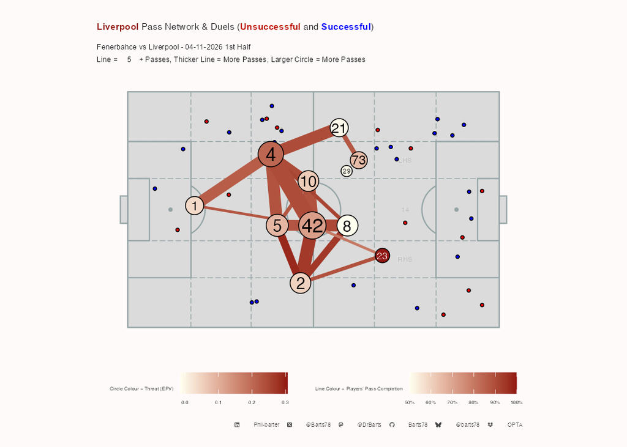

Home Pass Maps by Time

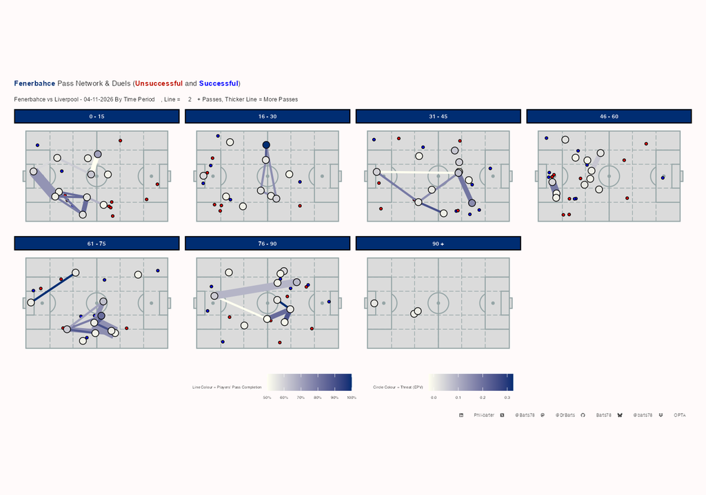

Away Pass Maps by Time

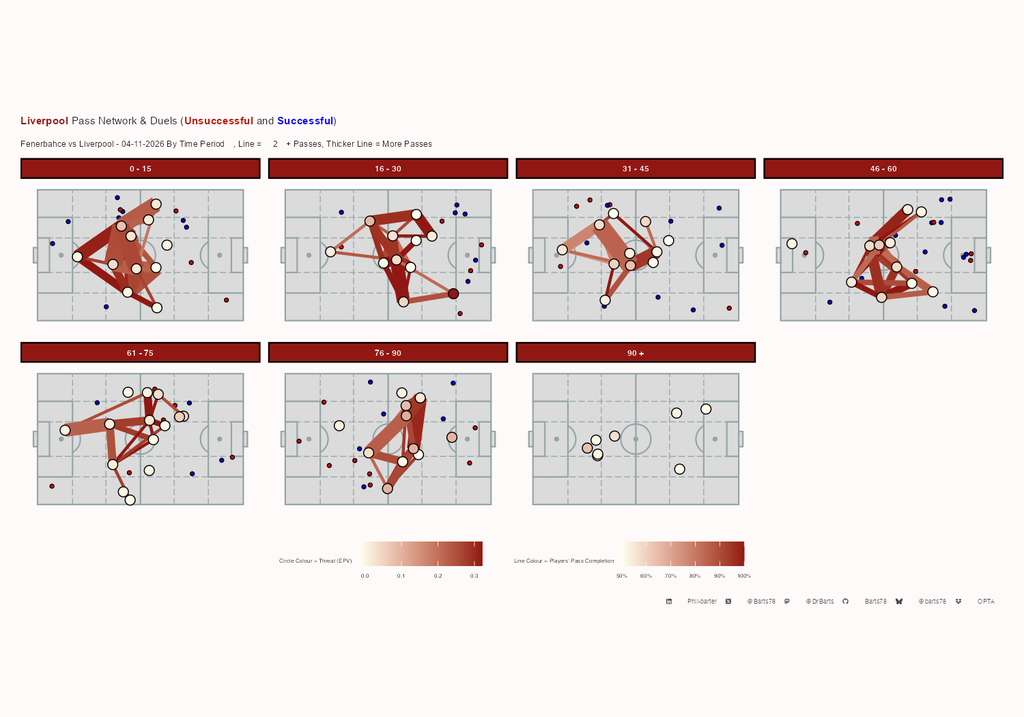

Home Attacking Pass Maps

[figure not shown]

Away Attacking Pass Maps

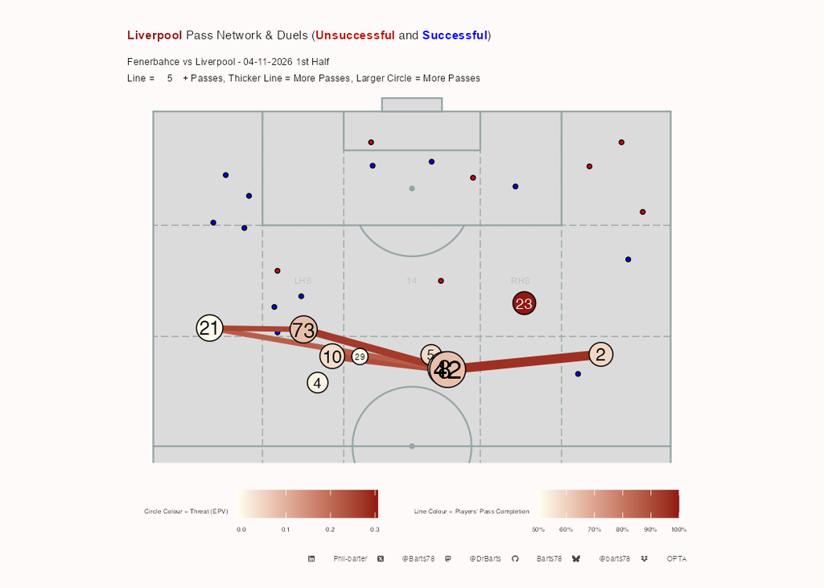

Home Attacking Pass Maps by Time

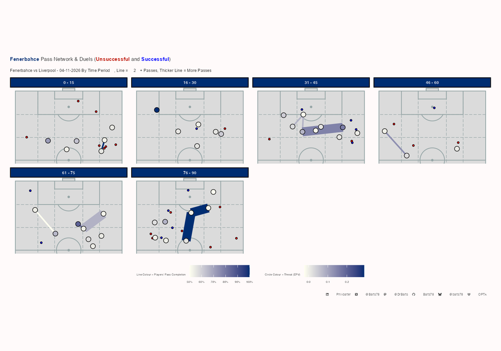

Away Attacking Pass Maps by Time

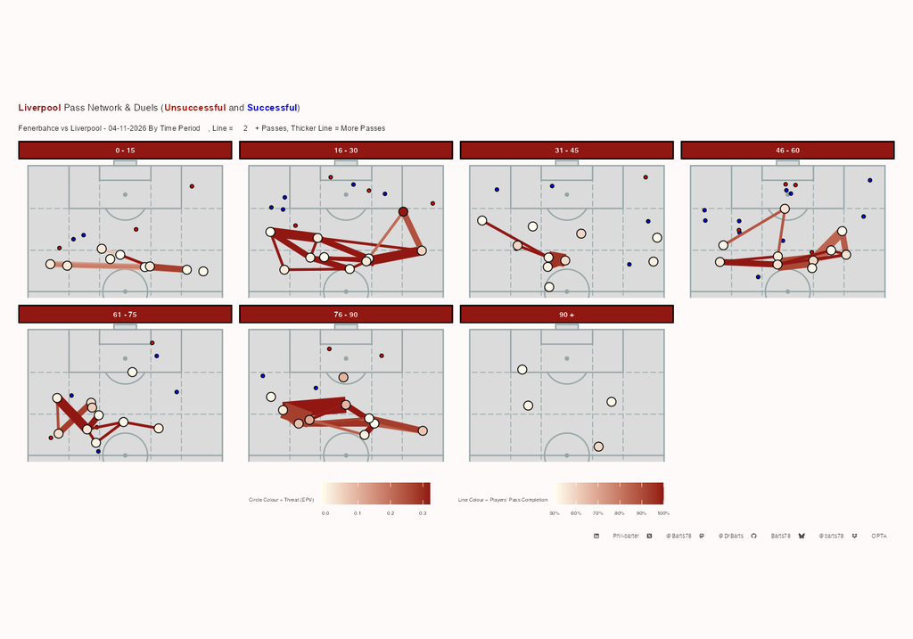

**Pass Connections by Passer**

Fenerbahce Open Play Passing connections

Fenerbahce vs Liverpool - 04-11-2026 | Completed passes only, min 5 per pair. Passer Completion % = all of the passer's attempts

|  | Completed Passes | % of Passer's Completions | % of Receiver's Receptions | Passer Completion % | Long Passes | Final Third Passes | PK Box Passes | Crosses | Key Passes | Prog Passes | EPV | EPV / Pass | Pass Time |
| --- | --- | --- | --- | --- | --- | --- | --- | --- | --- | --- | --- | --- | --- |
| Ismail Yüksek |  |  |  |  |  |  |  |  |  |  |  |  |  |
| Mason Greenwood | 5 | 20% | 22% | 83% | 0 | 1 | 0 | 0 | 0 | 1 | 0.017 | 0.003 | 3.00 |
| Mattéo Guendouzi | 6 | 24% | 33% | 83% | 0 | 0 | 0 | 0 | 0 | 0 | 0.019 | 0.003 | 2.67 |
| N'Golo Kanté | 5 | 20% | 24% | 83% | 0 | 2 | 0 | 0 | 0 | 2 | 0.018 | 0.004 | 2.20 |
| Mason Greenwood |  |  |  |  |  |  |  |  |  |  |  |  |  |
| Ismail Yüksek | 5 | 29% | 24% | 74% | 0 | 2 | 0 | 0 | 0 | 1 | 0.018 | 0.004 | 1.40 |
| Mattéo Guendouzi | 6 | 35% | 33% | 74% | 0 | 2 | 0 | 0 | 1 | 1 | 0.114 | 0.019 | 2.50 |
| Mattéo Guendouzi |  |  |  |  |  |  |  |  |  |  |  |  |  |
| Mason Greenwood | 5 | 23% | 22% | 79% | 0 | 3 | 0 | 0 | 1 | 0 | 0.029 | 0.006 | 5.20 |
| Milan Skriniar |  |  |  |  |  |  |  |  |  |  |  |  |  |
| Ederson | 11 | 41% | 73% | 79% | 1 | 0 | 0 | 0 | 0 | 0 | 0.017 | 0.002 | 2.64 |
| Nélson Semedo | 7 | 26% | 64% | 79% | 0 | 0 | 0 | 0 | 1 | 1 | 0.023 | 0.003 | 2.43 |
| N'Golo Kanté |  |  |  |  |  |  |  |  |  |  |  |  |  |
| Irfan Can Kahveci | 5 | 24% | 42% | 70% | 0 | 2 | 0 | 0 | 0 | 1 | 0.045 | 0.009 | 2.80 |
| Nélson Semedo |  |  |  |  |  |  |  |  |  |  |  |  |  |
| Milan Skriniar | 5 | 42% | 25% | 92% | 0 | 0 | 0 | 0 | 0 | 0 | 0.011 | 0.002 | 2.20 |

X @Barts78 · Bluesky @barts78 · Mastodon @DrBarts · GitHub Barts78 · LinkedIn Phil-barter · Data: Opta

**Pass Connections by Receiver**

Fenerbahce Open Play Passing connections

Fenerbahce vs Liverpool - 04-11-2026 | Completed passes only, min 5 per pair. Passer Completion % = all of the passer's attempts

|  | Completed Passes | % of Passer's Completions | % of Receiver's Receptions | Passer Completion % | Long Passes | Final Third Passes | PK Box Passes | Crosses | Key Passes | Prog Passes | EPV | EPV / Pass | Pass Time |
| --- | --- | --- | --- | --- | --- | --- | --- | --- | --- | --- | --- | --- | --- |
| Mason Greenwood |  |  |  |  |  |  |  |  |  |  |  |  |  |
| Ismail Yüksek | 5 | 20% | 22% | 83% | 0 | 1 | 0 | 0 | 0 | 1 | 0.017 | 0.003 | 3.00 |
| Mattéo Guendouzi | 5 | 23% | 22% | 79% | 0 | 3 | 0 | 0 | 1 | 0 | 0.029 | 0.006 | 5.20 |
| Mattéo Guendouzi |  |  |  |  |  |  |  |  |  |  |  |  |  |
| Ismail Yüksek | 6 | 24% | 33% | 83% | 0 | 0 | 0 | 0 | 0 | 0 | 0.019 | 0.003 | 2.67 |
| Mason Greenwood | 6 | 35% | 33% | 74% | 0 | 2 | 0 | 0 | 1 | 1 | 0.114 | 0.019 | 2.50 |
| N'Golo Kanté |  |  |  |  |  |  |  |  |  |  |  |  |  |
| Ismail Yüksek | 5 | 20% | 24% | 83% | 0 | 2 | 0 | 0 | 0 | 2 | 0.018 | 0.004 | 2.20 |
| Ismail Yüksek |  |  |  |  |  |  |  |  |  |  |  |  |  |
| Mason Greenwood | 5 | 29% | 24% | 74% | 0 | 2 | 0 | 0 | 0 | 1 | 0.018 | 0.004 | 1.40 |
| Ederson |  |  |  |  |  |  |  |  |  |  |  |  |  |
| Milan Skriniar | 11 | 41% | 73% | 79% | 1 | 0 | 0 | 0 | 0 | 0 | 0.017 | 0.002 | 2.64 |
| Nélson Semedo |  |  |  |  |  |  |  |  |  |  |  |  |  |
| Milan Skriniar | 7 | 26% | 64% | 79% | 0 | 0 | 0 | 0 | 1 | 1 | 0.023 | 0.003 | 2.43 |
| Irfan Can Kahveci |  |  |  |  |  |  |  |  |  |  |  |  |  |
| N'Golo Kanté | 5 | 24% | 42% | 70% | 0 | 2 | 0 | 0 | 0 | 1 | 0.045 | 0.009 | 2.80 |
| Milan Skriniar |  |  |  |  |  |  |  |  |  |  |  |  |  |
| Nélson Semedo | 5 | 42% | 25% | 92% | 0 | 0 | 0 | 0 | 0 | 0 | 0.011 | 0.002 | 2.20 |

X @Barts78 · Bluesky @barts78 · Mastodon @DrBarts · GitHub Barts78 · LinkedIn Phil-barter · Data: Opta

**Away Pass Connections by Passer**

Liverpool Open Play Passing connections

Fenerbahce vs Liverpool - 04-11-2026 | Completed passes only, min 5 per pair. Passer Completion % = all of the passer's attempts

|  | Completed Passes | % of Passer's Completions | % of Receiver's Receptions | Passer Completion % | Long Passes | Final Third Passes | PK Box Passes | Crosses | Key Passes | Prog Passes | EPV | EPV / Pass | Pass Time |
| --- | --- | --- | --- | --- | --- | --- | --- | --- | --- | --- | --- | --- | --- |
| Alexis Mac Allister |  |  |  |  |  |  |  |  |  |  |  |  |  |
| Dominik Szoboszlai | 5 | 10% | 11% | 92% | 0 | 0 | 0 | 0 | 0 | 0 | 0.006 | 0.001 | 2.20 |
| Joe Gomez | 5 | 10% | 12% | 92% | 0 | 0 | 0 | 0 | 0 | 0 | 0.012 | 0.002 | 3.80 |
| Jérémy Jacquet | 6 | 12% | 14% | 92% | 0 | 0 | 0 | 0 | 0 | 0 | 0.013 | 0.002 | 2.33 |
| Trey Nyoni | 11 | 23% | 16% | 92% | 0 | 2 | 0 | 0 | 0 | 0 | 0.017 | 0.002 | 2.27 |
| Virgil van Dijk | 5 | 10% | 8% | 92% | 0 | 0 | 0 | 0 | 0 | 0 | 0.012 | 0.002 | 4.20 |
| Alisson Becker |  |  |  |  |  |  |  |  |  |  |  |  |  |
| Virgil van Dijk | 11 | 52% | 18% | 72% | 0 | 0 | 0 | 0 | 0 | 0 | 0.005 | 0.000 | 4.36 |
| Dominik Szoboszlai |  |  |  |  |  |  |  |  |  |  |  |  |  |
| Alexis Mac Allister | 5 | 12% | 10% | 93% | 0 | 0 | 0 | 0 | 0 | 0 | 0.009 | 0.002 | 3.20 |
| Joe Gomez | 6 | 14% | 14% | 93% | 0 | 1 | 0 | 0 | 0 | 0 | 0.017 | 0.003 | 3.00 |
| Kostas Tsimikas | 5 | 12% | 18% | 93% | 1 | 2 | 0 | 0 | 0 | 0 | 0.036 | 0.007 | 2.60 |
| Rio Ngumoha | 5 | 12% | 26% | 93% | 0 | 2 | 0 | 0 | 0 | 1 | 0.024 | 0.005 | 2.60 |
| Trey Nyoni | 9 | 21% | 13% | 93% | 0 | 1 | 0 | 0 | 0 | 0 | 0.014 | 0.002 | 2.22 |
| Virgil van Dijk | 5 | 12% | 8% | 93% | 1 | 0 | 0 | 0 | 0 | 1 | 0.033 | 0.007 | 4.00 |
| Joe Gomez |  |  |  |  |  |  |  |  |  |  |  |  |  |
| Bradley Barcola | 5 | 12% | 21% | 100% | 1 | 0 | 0 | 0 | 0 | 2 | 0.033 | 0.007 | 2.60 |
| Dominik Szoboszlai | 6 | 15% | 13% | 100% | 0 | 2 | 0 | 0 | 0 | 3 | 0.041 | 0.007 | 2.67 |
| Jérémy Jacquet | 7 | 18% | 16% | 100% | 0 | 0 | 0 | 0 | 0 | 0 | 0.005 | 0.001 | 3.71 |
| Trey Nyoni | 7 | 18% | 10% | 100% | 0 | 1 | 0 | 0 | 0 | 0 | 0.014 | 0.002 | 3.71 |
| Víctor Muñoz | 8 | 20% | 38% | 100% | 1 | 2 | 0 | 0 | 0 | 2 | 0.044 | 0.006 | 3.88 |
| Jérémy Jacquet |  |  |  |  |  |  |  |  |  |  |  |  |  |
| Alexis Mac Allister | 7 | 14% | 15% | 88% | 0 | 0 | 0 | 0 | 0 | 2 | 0.017 | 0.002 | 1.57 |
| Alisson Becker | 6 | 12% | 27% | 88% | 0 | 0 | 0 | 0 | 0 | 0 | 0.003 | 0.000 | 3.50 |
| Dominik Szoboszlai | 5 | 10% | 11% | 88% | 0 | 0 | 0 | 0 | 0 | 2 | 0.012 | 0.002 | 4.20 |
| Joe Gomez | 5 | 10% | 12% | 88% | 0 | 0 | 0 | 0 | 1 | 0 | 0.012 | 0.002 | 3.40 |
| Trey Nyoni | 10 | 20% | 14% | 88% | 0 | 0 | 0 | 0 | 0 | 0 | 0.016 | 0.002 | 3.00 |
| Virgil van Dijk | 14 | 28% | 22% | 88% | 0 | 0 | 0 | 0 | 0 | 0 | 0.014 | 0.001 | 3.07 |
| Kostas Tsimikas |  |  |  |  |  |  |  |  |  |  |  |  |  |
| Rio Ngumoha | 6 | 23% | 32% | 93% | 0 | 2 | 0 | 0 | 0 | 1 | 0.025 | 0.004 | 3.00 |
| Trey Nyoni | 5 | 19% | 7% | 93% | 0 | 1 | 0 | 0 | 0 | 0 | 0.010 | 0.002 | 3.00 |
| Virgil van Dijk | 6 | 23% | 10% | 93% | 0 | 0 | 0 | 0 | 0 | 0 | 0.008 | 0.001 | 3.50 |
| Rio Ngumoha |  |  |  |  |  |  |  |  |  |  |  |  |  |
| Kostas Tsimikas | 5 | 28% | 18% | 90% | 0 | 3 | 0 | 0 | 0 | 0 | 0.032 | 0.006 | 1.40 |
| Trey Nyoni |  |  |  |  |  |  |  |  |  |  |  |  |  |
| Alexis Mac Allister | 10 | 12% | 21% | 92% | 0 | 0 | 0 | 0 | 0 | 6 | 0.035 | 0.004 | 2.40 |
| Bradley Barcola | 5 | 6% | 21% | 92% | 0 | 0 | 0 | 0 | 0 | 1 | 0.017 | 0.003 | 2.20 |
| Dominik Szoboszlai | 12 | 14% | 26% | 92% | 1 | 3 | 0 | 0 | 0 | 1 | 0.049 | 0.004 | 2.67 |
| Joe Gomez | 15 | 17% | 36% | 92% | 0 | 1 | 0 | 0 | 0 | 0 | 0.033 | 0.002 | 2.87 |
| Jérémy Jacquet | 8 | 9% | 19% | 92% | 0 | 0 | 0 | 0 | 0 | 0 | 0.021 | 0.003 | 2.88 |
| Kostas Tsimikas | 5 | 6% | 18% | 92% | 0 | 0 | 0 | 0 | 0 | 0 | 0.015 | 0.003 | 3.40 |
| Virgil van Dijk | 12 | 14% | 19% | 92% | 0 | 1 | 0 | 0 | 0 | 0 | 0.024 | 0.002 | 3.33 |
| Víctor Muñoz | 5 | 6% | 24% | 92% | 1 | 0 | 0 | 0 | 0 | 2 | 0.028 | 0.006 | 3.40 |
| Virgil van Dijk |  |  |  |  |  |  |  |  |  |  |  |  |  |
| Alexis Mac Allister | 12 | 17% | 25% | 87% | 0 | 0 | 0 | 0 | 0 | 3 | 0.034 | 0.003 | 1.58 |
| Alisson Becker | 8 | 11% | 36% | 87% | 0 | 0 | 0 | 0 | 0 | 0 | 0.008 | 0.001 | 2.88 |
| Dominik Szoboszlai | 5 | 7% | 11% | 87% | 1 | 1 | 0 | 0 | 0 | 0 | 0.021 | 0.004 | 3.00 |
| Jérémy Jacquet | 13 | 18% | 30% | 87% | 0 | 0 | 0 | 0 | 0 | 0 | 0.012 | 0.001 | 2.23 |
| Kostas Tsimikas | 7 | 10% | 26% | 87% | 0 | 0 | 0 | 0 | 0 | 0 | 0.024 | 0.003 | 2.71 |
| Trey Nyoni | 15 | 21% | 21% | 87% | 0 | 1 | 0 | 0 | 0 | 0 | 0.030 | 0.002 | 2.67 |

X @Barts78 · Bluesky @barts78 · Mastodon @DrBarts · GitHub Barts78 · LinkedIn Phil-barter · Data: Opta

**Away Pass Connections by Receiver**

Liverpool Open Play Passing connections

Fenerbahce vs Liverpool - 04-11-2026 | Completed passes only, min 5 per pair. Passer Completion % = all of the passer's attempts

|  | Completed Passes | % of Passer's Completions | % of Receiver's Receptions | Passer Completion % | Long Passes | Final Third Passes | PK Box Passes | Crosses | Key Passes | Prog Passes | EPV | EPV / Pass | Pass Time |
| --- | --- | --- | --- | --- | --- | --- | --- | --- | --- | --- | --- | --- | --- |
| Dominik Szoboszlai |  |  |  |  |  |  |  |  |  |  |  |  |  |
| Alexis Mac Allister | 5 | 10% | 11% | 92% | 0 | 0 | 0 | 0 | 0 | 0 | 0.006 | 0.001 | 2.20 |
| Joe Gomez | 6 | 15% | 13% | 100% | 0 | 2 | 0 | 0 | 0 | 3 | 0.041 | 0.007 | 2.67 |
| Jérémy Jacquet | 5 | 10% | 11% | 88% | 0 | 0 | 0 | 0 | 0 | 2 | 0.012 | 0.002 | 4.20 |
| Trey Nyoni | 12 | 14% | 26% | 92% | 1 | 3 | 0 | 0 | 0 | 1 | 0.049 | 0.004 | 2.67 |
| Virgil van Dijk | 5 | 7% | 11% | 87% | 1 | 1 | 0 | 0 | 0 | 0 | 0.021 | 0.004 | 3.00 |
| Joe Gomez |  |  |  |  |  |  |  |  |  |  |  |  |  |
| Alexis Mac Allister | 5 | 10% | 12% | 92% | 0 | 0 | 0 | 0 | 0 | 0 | 0.012 | 0.002 | 3.80 |
| Dominik Szoboszlai | 6 | 14% | 14% | 93% | 0 | 1 | 0 | 0 | 0 | 0 | 0.017 | 0.003 | 3.00 |
| Jérémy Jacquet | 5 | 10% | 12% | 88% | 0 | 0 | 0 | 0 | 1 | 0 | 0.012 | 0.002 | 3.40 |
| Trey Nyoni | 15 | 17% | 36% | 92% | 0 | 1 | 0 | 0 | 0 | 0 | 0.033 | 0.002 | 2.87 |
| Jérémy Jacquet |  |  |  |  |  |  |  |  |  |  |  |  |  |
| Alexis Mac Allister | 6 | 12% | 14% | 92% | 0 | 0 | 0 | 0 | 0 | 0 | 0.013 | 0.002 | 2.33 |
| Joe Gomez | 7 | 18% | 16% | 100% | 0 | 0 | 0 | 0 | 0 | 0 | 0.005 | 0.001 | 3.71 |
| Trey Nyoni | 8 | 9% | 19% | 92% | 0 | 0 | 0 | 0 | 0 | 0 | 0.021 | 0.003 | 2.88 |
| Virgil van Dijk | 13 | 18% | 30% | 87% | 0 | 0 | 0 | 0 | 0 | 0 | 0.012 | 0.001 | 2.23 |
| Trey Nyoni |  |  |  |  |  |  |  |  |  |  |  |  |  |
| Alexis Mac Allister | 11 | 23% | 16% | 92% | 0 | 2 | 0 | 0 | 0 | 0 | 0.017 | 0.002 | 2.27 |
| Dominik Szoboszlai | 9 | 21% | 13% | 93% | 0 | 1 | 0 | 0 | 0 | 0 | 0.014 | 0.002 | 2.22 |
| Joe Gomez | 7 | 18% | 10% | 100% | 0 | 1 | 0 | 0 | 0 | 0 | 0.014 | 0.002 | 3.71 |
| Jérémy Jacquet | 10 | 20% | 14% | 88% | 0 | 0 | 0 | 0 | 0 | 0 | 0.016 | 0.002 | 3.00 |
| Kostas Tsimikas | 5 | 19% | 7% | 93% | 0 | 1 | 0 | 0 | 0 | 0 | 0.010 | 0.002 | 3.00 |
| Virgil van Dijk | 15 | 21% | 21% | 87% | 0 | 1 | 0 | 0 | 0 | 0 | 0.030 | 0.002 | 2.67 |
| Virgil van Dijk |  |  |  |  |  |  |  |  |  |  |  |  |  |
| Alexis Mac Allister | 5 | 10% | 8% | 92% | 0 | 0 | 0 | 0 | 0 | 0 | 0.012 | 0.002 | 4.20 |
| Alisson Becker | 11 | 52% | 18% | 72% | 0 | 0 | 0 | 0 | 0 | 0 | 0.005 | 0.000 | 4.36 |
| Dominik Szoboszlai | 5 | 12% | 8% | 93% | 1 | 0 | 0 | 0 | 0 | 1 | 0.033 | 0.007 | 4.00 |
| Jérémy Jacquet | 14 | 28% | 22% | 88% | 0 | 0 | 0 | 0 | 0 | 0 | 0.014 | 0.001 | 3.07 |
| Kostas Tsimikas | 6 | 23% | 10% | 93% | 0 | 0 | 0 | 0 | 0 | 0 | 0.008 | 0.001 | 3.50 |
| Trey Nyoni | 12 | 14% | 19% | 92% | 0 | 1 | 0 | 0 | 0 | 0 | 0.024 | 0.002 | 3.33 |
| Alexis Mac Allister |  |  |  |  |  |  |  |  |  |  |  |  |  |
| Dominik Szoboszlai | 5 | 12% | 10% | 93% | 0 | 0 | 0 | 0 | 0 | 0 | 0.009 | 0.002 | 3.20 |
| Jérémy Jacquet | 7 | 14% | 15% | 88% | 0 | 0 | 0 | 0 | 0 | 2 | 0.017 | 0.002 | 1.57 |
| Trey Nyoni | 10 | 12% | 21% | 92% | 0 | 0 | 0 | 0 | 0 | 6 | 0.035 | 0.004 | 2.40 |
| Virgil van Dijk | 12 | 17% | 25% | 87% | 0 | 0 | 0 | 0 | 0 | 3 | 0.034 | 0.003 | 1.58 |
| Kostas Tsimikas |  |  |  |  |  |  |  |  |  |  |  |  |  |
| Dominik Szoboszlai | 5 | 12% | 18% | 93% | 1 | 2 | 0 | 0 | 0 | 0 | 0.036 | 0.007 | 2.60 |
| Rio Ngumoha | 5 | 28% | 18% | 90% | 0 | 3 | 0 | 0 | 0 | 0 | 0.032 | 0.006 | 1.40 |
| Trey Nyoni | 5 | 6% | 18% | 92% | 0 | 0 | 0 | 0 | 0 | 0 | 0.015 | 0.003 | 3.40 |
| Virgil van Dijk | 7 | 10% | 26% | 87% | 0 | 0 | 0 | 0 | 0 | 0 | 0.024 | 0.003 | 2.71 |
| Rio Ngumoha |  |  |  |  |  |  |  |  |  |  |  |  |  |
| Dominik Szoboszlai | 5 | 12% | 26% | 93% | 0 | 2 | 0 | 0 | 0 | 1 | 0.024 | 0.005 | 2.60 |
| Kostas Tsimikas | 6 | 23% | 32% | 93% | 0 | 2 | 0 | 0 | 0 | 1 | 0.025 | 0.004 | 3.00 |
| Bradley Barcola |  |  |  |  |  |  |  |  |  |  |  |  |  |
| Joe Gomez | 5 | 12% | 21% | 100% | 1 | 0 | 0 | 0 | 0 | 2 | 0.033 | 0.007 | 2.60 |
| Trey Nyoni | 5 | 6% | 21% | 92% | 0 | 0 | 0 | 0 | 0 | 1 | 0.017 | 0.003 | 2.20 |
| Víctor Muñoz |  |  |  |  |  |  |  |  |  |  |  |  |  |
| Joe Gomez | 8 | 20% | 38% | 100% | 1 | 2 | 0 | 0 | 0 | 2 | 0.044 | 0.006 | 3.88 |
| Trey Nyoni | 5 | 6% | 24% | 92% | 1 | 0 | 0 | 0 | 0 | 2 | 0.028 | 0.006 | 3.40 |
| Alisson Becker |  |  |  |  |  |  |  |  |  |  |  |  |  |
| Jérémy Jacquet | 6 | 12% | 27% | 88% | 0 | 0 | 0 | 0 | 0 | 0 | 0.003 | 0.000 | 3.50 |
| Virgil van Dijk | 8 | 11% | 36% | 87% | 0 | 0 | 0 | 0 | 0 | 0 | 0.008 | 0.001 | 2.88 |

X @Barts78 · Bluesky @barts78 · Mastodon @DrBarts · GitHub Barts78 · LinkedIn Phil-barter · Data: Opta

Home Passing Tree Plot

[figure not shown]

Away Passing Tree Plot

[figure not shown]

Home wave plot

[figure not shown]

Away wave plot

[figure not shown]

**Home 1st Half Pass receiving Areas**

[figure not shown]

**Home 2nd Half Pass receiving Areas**

[figure not shown]

**Home Up to 1st Sub Pass receiving Areas**

[figure not shown]

**Away 1st Half Pass receiving Areas**

[figure not shown]

**Away 2nd Half Pass receiving Areas**

[figure not shown]

**Away Up to 1st Sub Pass receiving Areas**

[figure not shown]

Home Passing chains

[figure not shown]

Away Passing Chains

[figure not shown]

**Full time**

Fenerbahce FT Passing Chain Length (5, 6-10, 11-15, 16 +) & Distance (m)

Fenerbahce vs Liverpool - 04-11-2026

|  | Pass Chain Length | Total Chain Passes | Max Chain Length | Average Chain Length | Percent of Teams Passes | Total Chain Distance | Max Chain Distance | Average Chain Distance | Percent of Teams Passing Distance |
| --- | --- | --- | --- | --- | --- | --- | --- | --- | --- |
|  | VLow | 145 | 5 | 2 | 72% | 2,427.96 | 122.35 | 16.70 | 73% |
|  | Low | 41 | 8 | 7 | 20% | 649.02 | 114.54 | 15.80 | 19% |
|  | High | 16 | 16 | 16 | 8% | 270.43 | 270.43 | 16.90 | 8% |
| Overall Totals | — | 202 | 29 | 25 | — | 3,347 | 507 | 49 | — |
| Overall Average | — | 67 | 10 | 8 | — | 1,116 | 169 | 16 | — |

X @Barts78 · Bluesky @barts78 · Mastodon @DrBarts · GitHub Barts78 · LinkedIn Phil-barter · Data: Opta

**1st Half**

Fenerbahce 1st Half Passing Chain Length (5, 6-10, 11-15, 16 +) & Distance (m)

Fenerbahce vs Liverpool - 04-11-2026

|  | Pass Chain Length | Total Chain Passes | Max Chain Length | Average Chain Length | Percent of Teams Passes | Total Chain Distance | Max Chain Distance | Average Chain Distance | Percent of Teams Passing Distance |
| --- | --- | --- | --- | --- | --- | --- | --- | --- | --- |
|  | VLow | 74 | 5 | 2 | 76% | 1,203.72 | 94.00 | 16.30 | 76% |
|  | Low | 7 | 7 | 7 | 7% | 114.54 | 114.54 | 16.40 | 7% |
|  | High | 16 | 16 | 16 | 16% | 270.43 | 270.43 | 16.90 | 17% |
| Overall Totals | — | 97 | 28 | 25 | — | 1,589 | 479 | 50 | — |
| Overall Average | — | 32 | 9 | 8 | — | 530 | 160 | 17 | — |

X @Barts78 · Bluesky @barts78 · Mastodon @DrBarts · GitHub Barts78 · LinkedIn Phil-barter · Data: Opta

**2nd Half**

Fenerbahce 2nd Half Passing Chain Length (5, 6-10, 11-15, 16 +) & Distance (m)

Fenerbahce vs Liverpool - 04-11-2026

|  | Pass Chain Length | Total Chain Passes | Max Chain Length | Average Chain Length | Percent of Teams Passes | Total Chain Distance | Max Chain Distance | Average Chain Distance | Percent of Teams Passing Distance |
| --- | --- | --- | --- | --- | --- | --- | --- | --- | --- |
|  | VLow | 71 | 4 | 2 | 68% | 1,224.24 | 122.35 | 17.20 | 70% |
|  | Low | 34 | 8 | 7 | 32% | 534.48 | 112.58 | 15.70 | 30% |
| Overall Totals | — | 105 | 12 | 9 | — | 1,759 | 235 | 33 | — |
| Overall Average | — | 52 | 6 | 4 | — | 879 | 117 | 16 | — |

X @Barts78 · Bluesky @barts78 · Mastodon @DrBarts · GitHub Barts78 · LinkedIn Phil-barter · Data: Opta

**Away Full time**

Liverpool FT Passing Chain Length (5, 6-10, 11-15, 16 +) & Distance (m)

Fenerbahce vs Liverpool - 04-11-2026

|  | Pass Chain Length | Total Chain Passes | Max Chain Length | Average Chain Length | Percent of Teams Passes | Total Chain Distance | Max Chain Distance | Average Chain Distance | Percent of Teams Passing Distance |
| --- | --- | --- | --- | --- | --- | --- | --- | --- | --- |
|  | VLow | 198 | 5 | 3 | 40% | 3,116.21 | 126.93 | 15.70 | 39% |
|  | Low | 99 | 10 | 7 | 20% | 1,573.56 | 172.44 | 15.90 | 20% |
|  | Medium | 115 | 14 | 13 | 23% | 1,798.37 | 257.53 | 15.60 | 23% |
|  | High | 87 | 27 | 22 | 17% | 1,482.52 | 486.33 | 17.00 | 19% |
| Overall Totals | — | 499 | 56 | 45 | — | 7,971 | 1,043 | 64 | — |
| Overall Average | — | 125 | 14 | 11 | — | 1,993 | 261 | 16 | — |

X @Barts78 · Bluesky @barts78 · Mastodon @DrBarts · GitHub Barts78 · LinkedIn Phil-barter · Data: Opta

**Away 1st Half**

Liverpool 1st Half Passing Chain Length (5, 6-10, 11-15, 16 +) & Distance (m)

Fenerbahce vs Liverpool - 04-11-2026

|  | Pass Chain Length | Total Chain Passes | Max Chain Length | Average Chain Length | Percent of Teams Passes | Total Chain Distance | Max Chain Distance | Average Chain Distance | Percent of Teams Passing Distance |
| --- | --- | --- | --- | --- | --- | --- | --- | --- | --- |
|  | VLow | 94 | 5 | 3 | 36% | 1,539.85 | 121.21 | 16.40 | 36% |
|  | Low | 44 | 9 | 7 | 17% | 694.30 | 140.32 | 15.80 | 16% |
|  | Medium | 63 | 13 | 13 | 24% | 993.95 | 242.57 | 15.80 | 23% |
|  | High | 60 | 25 | 20 | 23% | 1,067.15 | 486.33 | 17.80 | 25% |
| Overall Totals | — | 261 | 52 | 43 | — | 4,295 | 990 | 66 | — |
| Overall Average | — | 65 | 13 | 11 | — | 1,074 | 248 | 16 | — |

X @Barts78 · Bluesky @barts78 · Mastodon @DrBarts · GitHub Barts78 · LinkedIn Phil-barter · Data: Opta

**Away 2nd Half**

Liverpool 2nd Half Passing Chain Length (5, 6-10, 11-15, 16 +) & Distance (m)

Fenerbahce vs Liverpool - 04-11-2026

|  | Pass Chain Length | Total Chain Passes | Max Chain Length | Average Chain Length | Percent of Teams Passes | Total Chain Distance | Max Chain Distance | Average Chain Distance | Percent of Teams Passing Distance |
| --- | --- | --- | --- | --- | --- | --- | --- | --- | --- |
|  | VLow | 104 | 5 | 3 | 44% | 1,576.36 | 126.93 | 15.20 | 43% |
|  | Low | 55 | 10 | 7 | 23% | 879.26 | 172.44 | 16.00 | 24% |
|  | Medium | 52 | 14 | 13 | 22% | 804.42 | 257.53 | 15.50 | 22% |
|  | High | 27 | 27 | 27 | 11% | 415.37 | 415.37 | 15.40 | 11% |
| Overall Totals | — | 238 | 56 | 50 | — | 3,675 | 972 | 62 | — |
| Overall Average | — | 60 | 14 | 12 | — | 919 | 243 | 16 | — |

X @Barts78 · Bluesky @barts78 · Mastodon @DrBarts · GitHub Barts78 · LinkedIn Phil-barter · Data: Opta

**Home Z14 RS By Half**

[figure not shown]

**Home Z14 RS By Game Period**

[figure not shown]

**Away Z14 RS By Half**

[figure not shown]

**Away Z14 RS By Game Period**

[figure not shown]

**Home Long Passes By half**

[figure not shown]

**Home Long Passes By Game Period**

[figure not shown]

**Away Long Passes By Half**

[figure not shown]

**Away Long Passes By Game period**

[figure not shown]

Set-Piece Summary

**Set Pieces**

Fenerbahce vs Liverpool - 04-11-2026

|  | Fenerbahce | Liverpool |
| --- | --- | --- |
| Corners |  |  |
| Corners taken | 4 | 12 |
| Short | 1 | 0 |
| Direct | 3 | 12 |
| Direct - first contact won | 1 (33%) | 1 (8%) |
| Free kicks |  |  |
| Free kicks (passes) | 11 | 14 |
| Into final third / box | 4 | 4 |
| Into box | 0 | 1 |
| Throw-ins |  |  |
| Throw-ins | 14 | 12 |
| Retained (first touch) | 64% | 83% |
| Shots by situation |  |  |
| Open-play shots | 8 | 16 |
| Open-play xG | 0.99 | 1.26 |
| Open-play goals | 0 | 2 |
| Set-piece shots | 9 | 6 |
| Set-piece xG | 0.79 | 0.55 |
| Set-piece goals | 3 | 0 |
| Penalties | 0 | 0 |
| Penalty xG | 0.00 | 0.00 |
| Set-piece share of xG | 44% | 30% |

First contact: the team that touches the ball first after the delivery (aerial duels go to the winner). Throw-ins retained = first touch by the taking team.  
X @Barts78 · Bluesky @barts78 · Mastodon @DrBarts · GitHub Barts78 · LinkedIn Phil-barter · Data: Opta

**Corners**

[figure not shown]

**Free Kicks**

[figure not shown]

**Corners**

[figure not shown]

**Free Kicks**

[figure not shown]

**Sequence Map**

[figure not shown]

**Sequence Table**

**Fenerbahce - Shot-Creating Sequences**

Fenerbahce vs Liverpool - 04-11-2026

| Min | Shooter | Result | xG | Situation | Started by | Started from | Start zone | Passes | Duration (s) |
| --- | --- | --- | --- | --- | --- | --- | --- | --- | --- |
| 27' | Kahveci | Post | 0.62 | Open play | Guendouzi | Open-play regain | Mid third, Central | 7 | 14 |
| 29' | Greenwood | Goal | 0.06 | Set piece | Guendouzi | Open-play regain | Mid third, Right half-space | 3 | 64 |
| 34' | Guendouzi | Off target | 0.04 | Set piece | Greenwood | Free kick | Mid third, Right wing | 5 | 11 |
| 34' | Guendouzi | Blocked | 0.05 | Set piece | Greenwood | Free kick | Mid third, Right wing | 6 | 13 |
| 39' | Greenwood | Off target | 0.10 | Open play | Semedo | Open-play regain | Mid third, Right wing | 5 | 27 |
| 41' | Yüksek | Off target | 0.01 | Set piece | Kahveci | Corner | Att third, Left wing | 1 | 2 |
| 42' | Kanté | Off target | 0.06 | Open play | Kahveci | Open-play regain | Mid third, Central | 2 | 14 |
| 44' | Greenwood | Saved | 0.06 | Open play | Kahveci | Open-play regain | Mid third, Central | 2 | 6 |
| 59' | Brown | Saved | 0.02 | Open play | Kahveci | Open-play regain | Mid third, Central | 3 | 9 |
| 60' | Lukaku | Saved | 0.05 | Set piece | Kahveci | Corner | Att third, Left wing | 1 | 6 |
| 64' | Brown | Off target | 0.06 | Open play | Guendouzi | Open-play regain | Mid third, Right half-space | 3 | 15 |
| 71' | Greenwood | Blocked | 0.02 | Set piece | Kahveci | Free kick | Att third, Left wing | 1 | 2 |
| 73' | Semedo | Blocked | 0.02 | Open play | Guendouzi | Open-play regain | Att third, Central | 7 | 22 |
| 73' | Brown | Goal | 0.35 | Set piece | Greenwood | Corner | Att third, Right wing | 3 | 5 |
| 79' | Muriqi | Goal | 0.16 | Set piece | Brown | Throw-in | Att third, Right wing | 3 | 8 |
| 86' | Aktürkoglu | Off target | 0.05 | Set piece | Yüksek | Free kick | Mid third, Left wing | 2 | 75 |
| 90+1' | Guendouzi | Off target | 0.05 | Open play | Guendouzi | Open-play regain | Mid third, Right half-space | 1 | 5 |

X @Barts78 · Bluesky @barts78 · Mastodon @DrBarts · GitHub Barts78 · LinkedIn Phil-barter · Data: Opta

**Sequence Map**

[figure not shown]

**Sequence Table**

**Liverpool - Shot-Creating Sequences**

Fenerbahce vs Liverpool - 04-11-2026

| Min | Shooter | Result | xG | Situation | Started by | Started from | Start zone | Passes | Duration (s) |
| --- | --- | --- | --- | --- | --- | --- | --- | --- | --- |
| 3' | Muñoz | Off target | 0.11 | Open play | Muñoz | Open-play regain | Att third, Right half-space | 0 | 0 |
| 3' | Barcola | Off target | 0.22 | Open play | Muñoz | Open-play regain | Att third, Right half-space | 0 | 2 |
| 3' | Muñoz | Off target | 0.07 | Open play | Muñoz | Open-play regain | Att third, Right half-space | 0 | 5 |
| 4' | Jacquet | Off target | 0.36 | Set piece | Szoboszlai | Corner | Att third, Right wing | 2 | 7 |
| 13' | Szoboszlai | Blocked | 0.03 | Set piece | van Dijk | Open-play regain | Def third, Left wing | 12 | 103 |
| 20' | Jacquet | Blocked | 0.06 | Set piece | Szoboszlai | Corner | Att third, Right wing | 3 | 13 |
| 25' | Ngumoha | Blocked | 0.07 | Open play | Szoboszlai | Corner | Att third, Left wing | 10 | 35 |
| 25' | Nyoni | Goal | 0.07 | Open play | Szoboszlai | Corner | Att third, Left wing | 11 | 42 |
| 37' | Barcola | Off target | 0.06 | Open play | Nyoni | Open-play regain | Mid third, Central | 4 | 17 |
| 47' | Szoboszlai | Off target | 0.03 | Set piece | Gomez | Throw-in | Att third, Right wing | 1 | 4 |
| 49' | Ngumoha | Blocked | 0.03 | Open play | Jacquet | Goal kick | Def third, Central | 6 | 20 |
| 52' | Mac Allister | Saved | 0.03 | Set piece | Nyoni | Open-play regain | Att third, Central | 4 | 13 |
| 56' | Barcola | Saved | 0.03 | Open play | Szoboszlai | Open-play regain | Mid third, Left half-space | 2 | 5 |
| 57' | van Dijk | Saved | 0.04 | Set piece | Tsimikas | Corner | Att third, Left wing | 1 | 3 |
| 61' | Gomez | Off target | 0.03 | Open play | Jacquet | Open-play regain | Mid third, Central | 1 | 4 |
| 62' | Muñoz | Off target | 0.06 | Open play | Gomez | Open-play regain | Def third, Right wing | 12 | 41 |
| 69' | Isak | Goal | 0.30 | Open play | Nyoni | Open-play regain | Def third, Right wing | 7 | 35 |
| 82' | van Dijk | Saved | 0.04 | Open play | Szoboszlai | Corner | Att third, Right wing | 10 | 34 |
| 84' | Gakpo | Off target | 0.02 | Open play | van Dijk | Open-play regain | Mid third, Central | 7 | 15 |
| 88' | Isak | Off target | 0.08 | Open play | Koumas | Open-play regain | Def third, Central | 16 | 54 |
| 90+2' | Isak | Blocked | 0.04 | Open play | Szoboszlai | Open-play regain | Def third, Central | 2 | 8 |
| 90+3' | van Dijk | Off target | 0.03 | Open play | Szoboszlai | Throw-in | Att third, Right wing | 4 | 15 |

X @Barts78 · Bluesky @barts78 · Mastodon @DrBarts · GitHub Barts78 · LinkedIn Phil-barter · Data: Opta

Entries by Channel

**Box and Final-Third Entries (open play)**

Fenerbahce vs Liverpool - 04-11-2026

|  | Box entries Passes | Box entries Carries | Box entries Total | Box entries Success % | Final-third entries Passes | Final-third entries Carries | Final-third entries Total | Final-third entries Success % |
| --- | --- | --- | --- | --- | --- | --- | --- | --- |
| Fenerbahce |  |  |  |  |  |  |  |  |
| Left wing | 3 | 0 | 3 | 67% | 9 | 2 | 11 | 55% |
| Left half-space | 3 | 1 | 4 | 50% | 5 | 1 | 6 | 50% |
| Central | 4 | 1 | 5 | 20% | 12 | 1 | 13 | 38% |
| Right half-space | 2 | 1 | 3 | 67% | 7 | 0 | 7 | 86% |
| Right wing | 4 | 1 | 5 | 80% | 3 | 4 | 7 | 43% |
| Total | 16 | 4 | 20 | 55% | 36 | 8 | 44 | 52% |
| Liverpool |  |  |  |  |  |  |  |  |
| Left wing | 10 | 4 | 14 | 57% | 14 | 2 | 16 | 81% |
| Left half-space | 6 | 2 | 8 | 62% | 18 | 2 | 20 | 85% |
| Central | 1 | 0 | 1 | 100% | 15 | 2 | 17 | 76% |
| Right half-space | 3 | 1 | 4 | 25% | 14 | 0 | 14 | 93% |
| Right wing | 11 | 1 | 12 | 50% | 13 | 3 | 16 | 81% |
| Total | 31 | 8 | 39 | 54% | 74 | 9 | 83 | 83% |

Channel = where the pass or carry started. Left/right from the attacking team's view. Set pieces excluded.  
X @Barts78 · Bluesky @barts78 · Mastodon @DrBarts · GitHub Barts78 · LinkedIn Phil-barter · Data: Opta

**Box**

[figure not shown]

**Final Third**

[figure not shown]

**Box**

[figure not shown]

**Final Third**

[figure not shown]

**Match Stats**

**Passing stats**

Fenerbahce vs Liverpool - 04-11-2026

|  | Name | Mins | % of Team Possession | xA | xT | Attempted Passes | Successful Passes | Pass Success % | Assists | BCs | Key Passes | Long Ps | Final 3rd P | Prog Ps | PK Box P | Pass Received | PPs Received | KPs Recieved | Recieveing Suc | EPV Recieved | EPV Created | % of Team EPV |
| --- | --- | --- | --- | --- | --- | --- | --- | --- | --- | --- | --- | --- | --- | --- | --- | --- | --- | --- | --- | --- | --- | --- |
| Keeper | Ederson | 94 | 0.09 | 0 | 0.06 | 29 | 16 | 0.55 | 0 | 0 | 0 | 22 | 0 | 0 | 0 | 17 | 0 | 0 | 0.882352941176471 | 0.142 | 0.085 | 0.05 |
| Defender | Archie Brown | 94 | 0.1 | 0 | 0.56 | 21 | 10 | 0.48 | 1 | 1 | 3 | 9 | 6 | 4 | 1 | 25 | 0 | 2 | 0.72 | 0.126 | 0.601 | 0.36 |
| Defender | Kojo Peprah Oppong | 94 | 0.05 | 0 | 0 | 9 | 7 | 0.78 | 0 | 0 | 0 | 1 | 0 | 1 | 0 | 10 | 0 | 0 | 0.3 | 0.546 | 0.015 | 0.01 |
| Defender | Milan Skriniar | 94 | 0.11 | 0 | 0.07 | 34 | 27 | 0.79 | 0 | 0 | 1 | 6 | 2 | 2 | 1 | 24 | 0 | 0 | 0.833333333333333 | 0.183 | 0.118 | 0.07 |
| Defender | Nélson Semedo | 75 | 0.07 | 0.01 | 0.02 | 13 | 12 | 0.92 | 0 | 0 | 0 | 1 | 3 | 1 | 0 | 19 | 1 | 2 | 0.684210526315789 | 0.093 | 0.036 | 0.02 |
| Defender | Mert Müldür | 19 | 0.03 | 0 | 0 | 3 | 3 | 1 | 0 | 0 | 0 | 0 | 0 | 0 | 0 | 9 | 0 | 0 | 0.333333333333333 | 0.142 | 0.008 | 0 |
| Midfielder | Ismail Yüksek | 94 | 0.11 | 0 | 0.04 | 30 | 25 | 0.83 | 0 | 0 | 0 | 3 | 5 | 4 | 0 | 29 | 1 | 0 | 0.724137931034483 | 0.208 | 0.094 | 0.06 |
| Midfielder | Mattéo Guendouzi | 94 | 0.08 | 0.13 | 0.08 | 28 | 22 | 0.79 | 0 | 1 | 1 | 1 | 7 | 4 | 0 | 21 | 2 | 2 | 0.857142857142857 | 0.229 | 0.133 | 0.08 |
| Midfielder | N'Golo Kanté | 94 | 0.1 | 0.04 | 0.06 | 30 | 21 | 0.7 | 0 | 0 | 0 | 1 | 6 | 2 | 1 | 27 | 4 | 1 | 0.814814814814815 | 0.136 | 0.092 | 0.05 |
| Forward | Mason Greenwood | 90 | 0.1 | 0.06 | 0.21 | 23 | 17 | 0.74 | 0 | 0 | 2 | 2 | 9 | 5 | 1 | 28 | 4 | 4 | 0.892857142857143 | 0.155 | 0.256 | 0.15 |

[output cut: 5 more lines]

X @Barts78 · Bluesky @barts78 · Mastodon @DrBarts · GitHub Barts78 · LinkedIn Phil-barter · Data: Opta

**Touches and Carries**

Fenerbahce vs Liverpool - 04-11-2026

|  | Name | Mins | Touches | Def 3rd | Mid 3rd | Final 3rd | PK Box | Total / Min | Def 3rd % TT | Mid Third % TT | Final 3rd % TT | PK Box % TT | Carries | % Carries Prog | % Carries F 3rd | % Carries D Prog | Total Dribbles | Dribbles Won | Dribbles Lost | Dribble Success |
| --- | --- | --- | --- | --- | --- | --- | --- | --- | --- | --- | --- | --- | --- | --- | --- | --- | --- | --- | --- | --- |
| Keeper | Ederson | 94 | 41 | 41 | 0 | 0 | 0 | 0.436170212765957 | 1 | 0 | 0 | 0 | 7 | 0 | 0 | 0 | 0 | 0 | 0 | 0 |
| Defender | Archie Brown | 94 | 45 | 12 | 16 | 17 | 4 | 0.478723404255319 | 0.266666666666667 | 0.355555555555556 | 0.377777777777778 | 0.0888888888888889 | 5 | 0 | 0.6 | 0 | 0 | 0 | 0 | 0 |
| Defender | Kojo Peprah Oppong | 94 | 21 | 17 | 4 | 0 | 0 | 0.223404255319149 | 0.80952380952381 | 0.19047619047619 | 0 | 0 | 2 | 0 | 0 | 0 | 0 | 0 | 0 | 0 |
| Defender | Milan Skriniar | 94 | 48 | 38 | 8 | 2 | 1 | 0.51063829787234 | 0.791666666666667 | 0.166666666666667 | 0.0416666666666667 | 0.0208333333333333 | 6 | 0 | 0 | 0 | 0 | 0 | 0 | 0 |
| Defender | Nélson Semedo | 75 | 29 | 16 | 5 | 8 | 0 | 0.386666666666667 | 0.551724137931034 | 0.172413793103448 | 0.275862068965517 | 0 | 2 | 0 | 0 | 0 | 0 | 0 | 0 | 0 |
| Defender | Mert Müldür | 19 | 12 | 5 | 6 | 1 | 0 | 0.631578947368421 | 0.416666666666667 | 0.5 | 0.0833333333333333 | 0 | 2 | 0 | 0 | 0 | 1 | 0 | 1 | 0 |
| Midfielder | Ismail Yüksek | 94 | 50 | 22 | 22 | 6 | 0 | 0.531914893617021 | 0.44 | 0.44 | 0.12 | 0 | 3 | 0.333333333333333 | 0.333333333333333 | 0.441319835020622 | 0 | 0 | 0 | 0 |
| Midfielder | Mattéo Guendouzi | 94 | 36 | 11 | 14 | 11 | 2 | 0.382978723404255 | 0.305555555555556 | 0.388888888888889 | 0.305555555555556 | 0.0555555555555556 | 8 | 0.375 | 0.625 | 0.415411278496201 | 0 | 0 | 0 | 0 |
| Midfielder | N'Golo Kanté | 94 | 45 | 18 | 19 | 8 | 2 | 0.478723404255319 | 0.4 | 0.422222222222222 | 0.177777777777778 | 0.0444444444444444 | 1 | 0 | 1 | 0 | 2 | 1 | 1 | 0.5 |
| Forward | Mason Greenwood | 90 | 44 | 8 | 18 | 18 | 4 | 0.488888888888889 | 0.181818181818182 | 0.409090909090909 | 0.409090909090909 | 0.0909090909090909 | 2 | 0.5 | 0 | 0.79301948051948 | 3 | 1 | 2 | 0.333333333333333 |

[output cut: 5 more lines]

X @Barts78 · Bluesky @barts78 · Mastodon @DrBarts · GitHub Barts78 · LinkedIn Phil-barter · Data: Opta

**Shooting stats**

Fenerbahce vs Liverpool - 04-11-2026

|  | Name | Mins | Total Shots | SoT | 6 yard box | PK Box Shot | Out Box Shots | Blocked Shot | Goals | xG | xGOT | xG/Shot | Shot Accuracy | Shot Quality |
| --- | --- | --- | --- | --- | --- | --- | --- | --- | --- | --- | --- | --- | --- | --- |
| Keeper | Ederson | 94 | 0 | 0 | 0 | 0 | 0 | 0 | 0 | 0 | 0 | 0 | 0 | 0 |
| Defender | Archie Brown | 94 | 3 | 2 | 1 | 2 | 1 | 0 | 1 | 0.43 | 1.1 | 0.143333333333333 | 0.666666666666667 | 1.55813953488372 |
| Defender | Kojo Peprah Oppong | 94 | 0 | 0 | 0 | 0 | 0 | 0 | 0 | 0 | 0 | 0 | 0 | 0 |
| Defender | Milan Skriniar | 94 | 0 | 0 | 0 | 0 | 0 | 0 | 0 | 0 | 0 | 0 | 0 | 0 |
| Defender | Nélson Semedo | 75 | 1 | 0 | 0 | 0 | 1 | 1 | 0 | 0.02 | 0 | 0.02 | 0 | -1 |
| Defender | Mert Müldür | 19 | 0 | 0 | 0 | 0 | 0 | 0 | 0 | 0 | 0 | 0 | 0 | 0 |
| Midfielder | Ismail Yüksek | 94 | 1 | 0 | 0 | 0 | 1 | 0 | 0 | 0.01 | 0 | 0.01 | 0 | -1 |
| Midfielder | Mattéo Guendouzi | 94 | 3 | 0 | 0 | 2 | 1 | 1 | 0 | 0.14 | 0 | 0.0466666666666667 | 0 | -1 |
| Midfielder | N'Golo Kanté | 94 | 1 | 0 | 0 | 1 | 0 | 0 | 0 | 0.06 | 0 | 0.06 | 0 | -1 |
| Forward | Mason Greenwood | 90 | 4 | 2 | 0 | 2 | 2 | 1 | 1 | 0.24 | 0.26 | 0.06 | 0.5 | 0.0833333333333334 |

[output cut: 5 more lines]

X @Barts78 · Bluesky @barts78 · Mastodon @DrBarts · GitHub Barts78 · LinkedIn Phil-barter · Data: Opta

**Defensive stats**

Fenerbahce vs Liverpool - 04-11-2026